# Cariaco_Euks_PostAnalysis

Liz Suter

5/26/2020

# Load libraries

```r
library(tidyverse)
library(phyloseq)
library(dada2)
library(Biostrings)
# library(DECIPHER)
library(phangorn)
library(readr)
library(seqinr)
# library(decontam)
library(ape)
library(vegan)
#library(philr)
library(RColorBrewer)
library(microbiome)
library(DESeq2)
library(compositions)
library(cowplot)
library(plotly)
library(htmlwidgets)
library(withr)
```

# Prepare the data

## Import

Metadata:

```r
metadata <- read_csv("Metadata.csv")
```

Import SRA table and match SRA IDs with sample IDs in metadata file

```r
SRARunTable <- read_csv("sra_data/SraRunTable.txt")
metadata <- left_join(metadata, SRARunTable, by = 'Sample Name')
```

DADA2 results:

```r
# Import Count table. Skip first row of tsv file, which is just some text
count_table <- read_tsv(file="dada2_export/ASVs_counts.tsv")
# And specify that the first column of data are rownames
count_table <- column_to_rownames(count_table, var = colnames(count_table)[1])

# Import taxonomy of ASVs
taxonomy <- read_tsv(file="dada2_export/ASVs_taxonomy.tsv")
# And specify that the first column of data are rownames
taxonomy <- column_to_rownames(taxonomy, var = colnames(taxonomy)[1])
```

## QC and Filtering

### Rarefaction curves

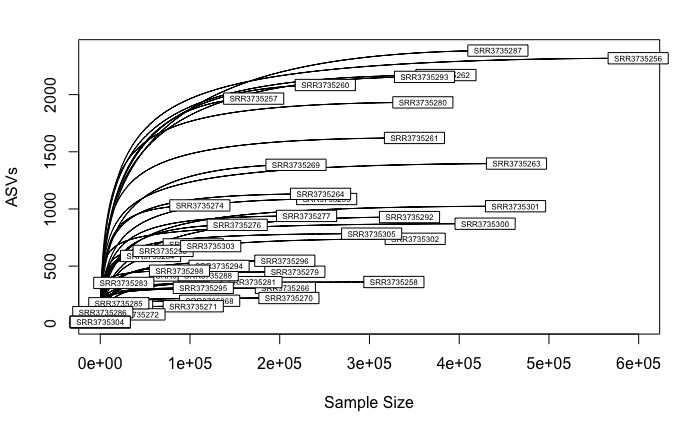

```r
# Use rarecurve, from the Vegan package. Rarcurve expects the dataset as a dataframe so we need to use as.data.frame again:
count_table_df <- as.data.frame(count_table)

# Plot the rarefaction curves, color-coding by the colors listed in sample_info_tab, which indicate sample type, and transforming using t() again
# Running this 5-10 samples at a time because otherwise it takes a long time to render
rarecurve(t(count_table_df), step=100, cex=0.5, ylab="ASVs", label=T)
```

### Remove singletons

```r
count_table_no_singletons <- filter(count_table,rowSums(count_table)>1)
# retains all ASVs (out of 14176)
```

and change sample names from NCBI ID to our internal sample IDs

```r
# Modify taxa names in count_table_no_singletons, which are the NCBI SRA numbers. Want to use our internal sample key
key <- SRARunTable %>% select(Run, 'Sample Name')

x <- (t(count_table_no_singletons))
x <- as.data.frame(cbind(x, Run = rownames(x)))

y <- t(left_join(x, key, by = "Run"))
colnames(y) <- y['Sample Name',]
y <- y[ !(rownames(y) %in% c('Sample Name', 'Run')), ]

count_table_2 <- type_convert(as.data.frame(y))
```

### Make Phylo Tree

This process takes a LONG time so run once and save .RData object In the Dada2 tools, there are no options to build a tree (unlike in Qiime2) but we can build it here using DECIPHER and phangorn

(Based on https://f1000research.com/articles/5-1492/v2)

Make an alignment using tools from Decipher (Note- alignment step takes several hours. Commented out for now. Only need to run once)

```r
## import fasta
# fas <- "dada2_export/ASVs.fa"
# seqs <- readDNAStringSet(fas)
# seqs
#
# # perform the alignment
# aligned <- AlignSeqs(seqs) # automatically detects and uses all cores
#
# # view the alignment in a browser (optional)
# BrowseSeqs(aligned, highlight=0)
#
# # write out aligned sequence file
# writeXStringSet(aligned, file="ASVs.aligned.fasta")
```

Use phangorn package to build tree. Here we are building a maximum likelihood neighbor-joining tree. (Also takes a while to run. Comment out for now.)

```r
# phang.align <- phyDat(as(aligned, "matrix"), type="DNA") # convert to phyDat format
# dm <- dist.ml(phang.align) # calculate pairwise distance matrix
# treeNJ <- NJ(dm) # perform neighbor-joining tree method
# fit = pml(treeNJ, data=phang.align) # compute intermal max likelihood
```

#### Save and re-load dataset

Since the step above takes a long time, save all variables up to this point in environment as RData object

```r
save.image("EnvironmentBackups/CariacoEuks_postanalysis_vars_upto_tree.RData")
```

Re-load

```r
load("EnvironmentBackups/CariacoEuks_postanalysis_vars_upto_tree.RData")
```

### Make phyloseq objects

Here we will do ordinations using the phyloseq package, which first requires making phyloseq objects out of each of our input data tables (in the last tutorial, I imported the tree using phyloseq so it is already a phyloseq object)

```r
ASV =   otu_table(count_table_2, taxa_are_rows =  TRUE)
TAX =   tax_table(as.matrix(taxonomy))
META    =   sample_data(data.frame(metadata, row.names = metadata$`Sample Name`))
TREE = phy_tree(fit$tree)
```

First check that the inputs are in compatible formats by checking for ASV names with the phyloseq function, taxa_names

```r
head(taxa_names(TAX))
```

```
[1] "ASV_1" "ASV_2" "ASV_3" "ASV_4" "ASV_5" "ASV_6"
```

```r
head(taxa_names(ASV))
```

```
[1] "ASV_1" "ASV_2" "ASV_3" "ASV_4" "ASV_5" "ASV_6"
```

```r
head(taxa_names(TREE))
```

```
[1] "ASV_1" "ASV_2" "ASV_3" "ASV_4" "ASV_5" "ASV_6"
```

And check sample names were also detected

```r
head(sample_names(ASV))
```

```
[1] "AE3a103A"  "AE3b103A"  "AE1b900AM" "AE3a103B"  "AE3b103B"  "AE3a198B"
```

```r
head(sample_names(META))
```

```
[1] "AE3a103A" "AE3b103A" "AE3a198A" "AE3b198A" "AE3a234A" "AE3b234A"
```

And make the phyloseq object

```r
ps <- phyloseq(ASV, TAX,    META , TREE)
```

Check some features of the phyloseq object

```r
rank_names(ps)
```

```
[1] "Kingdom"    "Supergroup" "Division"   "Class"      "Order"      "Family"
[7] "Genus"      "Species"
```

```r
table(tax_table(ps)[, "Supergroup"], exclude = NULL)
```

```
     Alveolata      Amoebozoa       Apusozoa Archaeplastida       Excavata
          8880              9             45            108              9
      Hacrobia   Opisthokonta       Rhizaria  Stramenopiles           <NA>
           395            768           2405           1086            471
```

```r
unique(tax_table(ps)[, "Supergroup"])
```

```
Taxonomy Table:     [10 taxa by 1 taxonomic ranks]:
         Supergroup
ASV_1    "Alveolata"
ASV_2    "Rhizaria"
ASV_6    "Stramenopiles"
ASV_18   "Opisthokonta"
ASV_78   "Hacrobia"
ASV_148  "Archaeplastida"
ASV_193  NA
ASV_557  "Apusozoa"
ASV_1114 "Amoebozoa"
ASV_2665 "Excavata"
```

Filter out those ambigious Supergroup annotations- losing 471 ASVs

```r
ps <- subset_taxa(ps, !is.na(Supergroup) & !Supergroup %in% c("", "NA"))
table(tax_table(ps)[, "Supergroup"], exclude = NULL)
```

```
     Alveolata      Amoebozoa       Apusozoa Archaeplastida       Excavata       Hacrobia   Opisthokonta       Rhizaria
          8880              9             45            108              9            395            768           2405
 Stramenopiles
          1086
```

Check out the Division names

```r
table(tax_table(ps)[, "Division"], exclude = NULL)
```

```
        Apicomplexa      Apusomonadidae      Centroheliozoa            Cercozoa         Chlorophyta    Choanoflagellida
                 29                  26                  40                 246                  64                  54
         Ciliophora         Cryptophyta      Dinoflagellata             Discoba        Foraminifera               Fungi
                407                  50                8330                   1                   2                  57
         Haptophyta         Hilomonadea Katablepharidophyta              Lobosa       Mesomycetozoa          Metamonada
                215                  17                   2                   9                  17                   8
            Metazoa          Ochrophyta            Opalozoa      Opisthokonta_X           Perkinsea             Picozoa
                561                 453                 216                  14                   5                  61
        Pseudofungi          Radiolaria          Rhodophyta           Sagenista     Stramenopiles_X        Streptophyta
                 72                2155                   4                 186                  61                  38
          Telonemia                <NA>
                 27                 278
```

Filter out any with “NA” as Division

```r
ps <- subset_taxa(ps, !is.na(Division) & !Division %in% c(""))
table(tax_table(ps)[, "Division"], exclude = NULL)
```

```
        Apicomplexa      Apusomonadidae      Centroheliozoa            Cercozoa         Chlorophyta    Choanoflagellida
                 29                  26                  40                 246                  64                  54
         Ciliophora         Cryptophyta      Dinoflagellata             Discoba        Foraminifera               Fungi
                407                  50                8330                   1                   2                  57
         Haptophyta         Hilomonadea Katablepharidophyta              Lobosa       Mesomycetozoa          Metamonada
                215                  17                   2                   9                  17                   8
            Metazoa          Ochrophyta            Opalozoa      Opisthokonta_X           Perkinsea             Picozoa
                561                 453                 216                  14                   5                  61
        Pseudofungi          Radiolaria          Rhodophyta           Sagenista     Stramenopiles_X        Streptophyta
                 72                2155                   4                 186                  61                  38
          Telonemia
                 27
```

Eliminate the libraries that didn’t have many sequences, AE3a198A, AE3b314A, AE2a200A, AE2b900AN, AE2a200B, AE2a267B, AE2a900BN

```r
taxa_to_keep <- !sample_names(ps) %in% c("AE3a198A","AE3b314A","AE2a200A","AE2b900AN","AE2a200B","AE2a267B","AE2a900BN")
ps <- prune_samples(taxa_to_keep, ps)
```

41 samples remain and stil 13,427 ASVs

Check rarefaction curve again to make sure those low-sqeuencing-effort samples have been removed

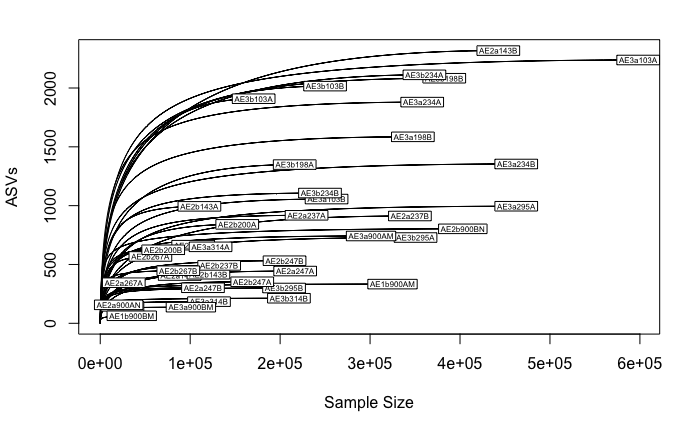

```r
rarecurve(t(otu_table(ps)), step=100, cex=0.5, ylab="ASVs", label=T)
```

### Re-root tree

Have to do this because you may have removed the root of your tree when pruning). (I found this handy function from [here](https://john-quensen.com/r/unifrac-and-tree-roots/) which picks the longest branch to root from).

```r
# first define function from link above to find furthest outgroup
pick_new_outgroup <- function(tree.unrooted){
require("magrittr")
require("data.table")
require("ape") # ape::Ntip
# tablify parts of tree that we need.
treeDT <-
     cbind(
         data.table(tree.unrooted$edge),
         data.table(length = tree.unrooted$edge.length)
     )[1:Ntip(tree.unrooted)] %>%
 cbind(data.table(id = tree.unrooted$tip.label))
 # Take the longest terminal branch as outgroup
 new.outgroup <- treeDT[which.max(length)]$id
 return(new.outgroup) }

# then run on my phyloseq tree
my.tree <- phy_tree(ps)
out.group <- pick_new_outgroup(my.tree)
```

[output not shown]

```r
out.group
```

```
[1] "ASV_10740"
```

```r
# Then use this outgroup to root the tree
new.tree1 <- ape::root(my.tree, outgroup=out.group, resolve.root=TRUE)


phy_tree(ps) <- new.tree1

# Check if tree is binary (dichotomous not multichotomous)
is.binary.tree(phy_tree(ps))
```

```
[1] TRUE
```

```r
# If false, would have to run
# new.tree2 <- ape::multi2di(new.tree1)
# phy_tree(ps) <- new.tree2
# phy_tree(ps)
```

### Check phyla using bar plots

Check overall how the phyla are distributed among samples. Phyloseq makes this easy

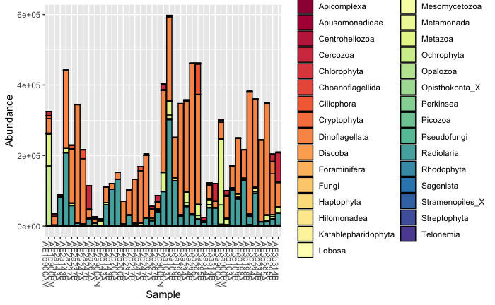

```r
# First aglomerate the ASVs at the phylum level using the phyloseq function, tax_glom
DivisionGlommed = tax_glom(ps, "Division")

# There are many phyla here, so have to make a custom color palette by interpolating from an existing one in RColorBrewer
colourCount = length(table(tax_table(ps)[, "Division"], exclude = NULL))
getPalette = colorRampPalette(brewer.pal(11, "Spectral"))
DivisionPalette = getPalette(colourCount)

# and plot
plot_bar(DivisionGlommed, x = "Sample", fill = "Division") +
  scale_fill_manual(values = DivisionPalette)
```

Plot compositional (relative abundances) instead of absolute abundance using microbiome::transform

```r
(otu_table(ps_ra))[1:10,1:10]
```

```
OTU Table:          [10 taxa and 10 samples]
                     taxa are rows
           AE3a103A    AE3b103A    AE1b900AM     AE3a103B     AE3b103B     AE3a198B     AE3b198B     AE3a234B     AE3b234B
ASV_1  4.046390e-04 0.000105531 2.462054e-05 0.000000e+00 2.400346e-05 0.0000000000 0.000000e+00 0.000000e+00 0.000000e+00
ASV_2  0.000000e+00 0.000000000 3.132963e-02 0.000000e+00 5.600807e-05 0.0000000000 2.614543e-05 4.324530e-06 8.186321e-05
ASV_3  6.674871e-03 0.014117702 2.265089e-02 3.696079e-03 1.055352e-02 0.0109040900 2.340539e-02 4.713738e-03 3.297450e-02
ASV_4  1.244014e-03 0.001524337 1.231027e-05 4.769134e-05 6.720968e-04 0.0342140999 3.424529e-02 1.010816e-01 1.305718e-01
ASV_5  2.675299e-05 0.000000000 0.000000e+00 7.948557e-06 1.040150e-04 0.0002704444 3.085161e-04 3.606658e-03 3.118988e-03
ASV_6  8.377030e-03 0.005464161 4.328167e-01 0.000000e+00 0.000000e+00 0.0010587612 2.614543e-05 1.210868e-04 0.000000e+00
ASV_7  0.000000e+00 0.000000000 0.000000e+00 0.000000e+00 0.000000e+00 0.0000000000 0.000000e+00 0.000000e+00 0.000000e+00
ASV_8  5.822119e-03 0.001700222 6.155134e-06 0.000000e+00 4.800691e-05 0.0006789882 7.843629e-05 3.892077e-05 0.000000e+00
ASV_9  5.236898e-03 0.026664165 0.000000e+00 9.114610e-02 2.457954e-02 0.0059210072 2.682521e-03 2.594718e-03 1.448979e-03
ASV_10 9.932047e-04 0.002040266 1.846540e-05 6.994730e-04 6.560945e-04 0.0046320805 1.349104e-03 2.560122e-03 8.431910e-04
           AE3a295B
ASV_1  0.0033206447
ASV_2  0.3831700008
ASV_3  0.0168461975
ASV_4  0.0000000000
ASV_5  0.0000000000
ASV_6  0.0002429740
ASV_7  0.0006479307
ASV_8  0.0000000000
ASV_9  0.0000000000
ASV_10 0.0012148700
```

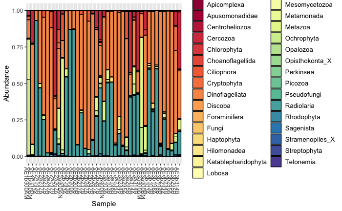

```r
# Then aglomerate the ASVs at the phylum level using the phyloseq function, tax_glom
DivisionGlommed_RA = tax_glom(ps_ra, "Division")
# and plot
Division_barplot <- plot_bar(DivisionGlommed_RA, x = "Sample", fill = "Division") +
  scale_fill_manual(values = DivisionPalette) +
  theme(legend.text = element_text(size = 10))


Division_barplot

# export
ggsave("Figures/Division_barplot.eps",Division_barplot, width = 15, height = 5, units = c("in"))
```

Lots of dinoflagellates and radiolaria. Makes sense. But the above is the distribution from all samples. Next make plots that indicate distributions across environmental gradients. Calculate averages and use bubble plots

### Calculate averages from replicates

Get average relative abundances from sample replicates

```r
otu_table_mean_ra <-
  mutate(data.frame(otu_table(ps_ra)), "103A" = rowMeans(select(data.frame(otu_table(ps_ra)), c("AE3a103A","AE3b103A")), na.rm = TRUE)) %>%
  mutate(data.frame(otu_table(ps_ra)), "198A" = rowMeans(select(data.frame(otu_table(ps_ra)), c("AE3b198A")), na.rm = TRUE))  %>% # Sample AE3a198A was removed
  mutate(data.frame(otu_table(ps_ra)), "234A" = rowMeans(select(data.frame(otu_table(ps_ra)), c("AE3a234A","AE3b234A")), na.rm = TRUE)) %>%
  mutate(data.frame(otu_table(ps_ra)), "295A" = rowMeans(select(data.frame(otu_table(ps_ra)), c("AE3a295A","AE3b295A")), na.rm = TRUE)) %>%
  mutate(data.frame(otu_table(ps_ra)), "314A" = rowMeans(select(data.frame(otu_table(ps_ra)), c("AE3a314A")), na.rm = TRUE)) %>%  # Sample AE3b314A was removed
  mutate(data.frame(otu_table(ps_ra)), "900AM" = rowMeans(select(data.frame(otu_table(ps_ra)), c("AE3a900AM","AE1b900AM")), na.rm = TRUE)) %>%
  mutate(data.frame(otu_table(ps_ra)), "103B" = rowMeans(select(data.frame(otu_table(ps_ra)), c("AE3a103B","AE3b103B")), na.rm = TRUE)) %>%
  mutate(data.frame(otu_table(ps_ra)), "198B" = rowMeans(select(data.frame(otu_table(ps_ra)), c("AE3a198B","AE3b198B")), na.rm = TRUE)) %>%
  mutate(data.frame(otu_table(ps_ra)), "234B" = rowMeans(select(data.frame(otu_table(ps_ra)), c("AE3a234B","AE3b234B")), na.rm = TRUE)) %>%
  mutate(data.frame(otu_table(ps_ra)), "295B" = rowMeans(select(data.frame(otu_table(ps_ra)), c("AE3a295B","AE3b295B")), na.rm = TRUE)) %>%
  mutate(data.frame(otu_table(ps_ra)), "314B" = rowMeans(select(data.frame(otu_table(ps_ra)), c("AE3a314B","AE3b314B")), na.rm = TRUE)) %>%
  mutate(data.frame(otu_table(ps_ra)), "900BM" = rowMeans(select(data.frame(otu_table(ps_ra)), c("AE3a900BM","AE1b900BM")), na.rm = TRUE)) %>%
  mutate(data.frame(otu_table(ps_ra)), "143A" = rowMeans(select(data.frame(otu_table(ps_ra)), c("AE2a143A","AE2b143A")), na.rm = TRUE)) %>%
  mutate(data.frame(otu_table(ps_ra)), "200A" = rowMeans(select(data.frame(otu_table(ps_ra)), c("AE2b200A")), na.rm = TRUE)) %>% # AE2a200A was removed
  mutate(data.frame(otu_table(ps_ra)), "237A" = rowMeans(select(data.frame(otu_table(ps_ra)), c("AE2a237A","AE2b237A")), na.rm = TRUE)) %>%
  mutate(data.frame(otu_table(ps_ra)), "247A" = rowMeans(select(data.frame(otu_table(ps_ra)), c("AE2a247A","AE2b247A")), na.rm = TRUE)) %>%
  mutate(data.frame(otu_table(ps_ra)), "267A" = rowMeans(select(data.frame(otu_table(ps_ra)), c("AE2a267A","AE2b267A")), na.rm = TRUE)) %>%
  mutate(data.frame(otu_table(ps_ra)), "900AN" = rowMeans(select(data.frame(otu_table(ps_ra)), c("AE2a900AN")), na.rm = TRUE)) %>% # AE2b900AN was removed
  mutate(data.frame(otu_table(ps_ra)), "143B" = rowMeans(select(data.frame(otu_table(ps_ra)), c("AE2a143B","AE2b143B")), na.rm = TRUE)) %>%
  mutate(data.frame(otu_table(ps_ra)), "200B" = rowMeans(select(data.frame(otu_table(ps_ra)), c("AE2b200B")), na.rm = TRUE)) %>% # AE2a200B was removed
  mutate(data.frame(otu_table(ps_ra)), "237B" = rowMeans(select(data.frame(otu_table(ps_ra)), c("AE2a237B","AE2b237B")), na.rm = TRUE)) %>%
  mutate(data.frame(otu_table(ps_ra)), "247B" = rowMeans(select(data.frame(otu_table(ps_ra)), c("AE2a247B","AE2b247B")), na.rm = TRUE)) %>%
  mutate(data.frame(otu_table(ps_ra)), "267B" = rowMeans(select(data.frame(otu_table(ps_ra)), c("AE2b267B")), na.rm = TRUE)) %>% # AE2a267B was removed
  mutate(data.frame(otu_table(ps_ra)), "900BN" = rowMeans(select(data.frame(otu_table(ps_ra)), c("AE2b900BN")), na.rm = TRUE)) # AE2a900BN was removed

otu_table_mean_ra <- otu_table_mean_ra[,unique(metadata$Replicate)]

#otu_table_mean_ra <- as_tibble(otu_table_mean_ra, rownames = "SampleID")

otu_table_mean_ra
```

|  | 103A | 198A | 234A | 295A | 314A | 900AM | 103B | 198B | 234B | 295B | 314B | 900BM | 143A | 200A | 237A | 247A | 267A | 900AN | 143B | 200B | 237B | 247B | 267B | 900BN |
| --- | --- | --- | --- | --- | --- | --- | --- | --- | --- | --- | --- | --- | --- | --- | --- | --- | --- | --- | --- | --- | --- | --- | --- | --- |
| ASV_1 | 2.550850e-04 | 0.000000e+00 | 6.574970e-04 | 1.969041e-01 | 9.899214e-03 | 6.502754e-03 | 1.200173e-05 | 0.000000e+00 | 0.000000e+00 | 1.837576e-02 | 2.141747e-02 | 1.366112e-02 | 1.925728e-04 | 0.000000e+00 | 1.369590e-02 | 4.683226e-01 | 5.713842e-02 | 0.000000e+00 | 1.247256e-04 | 2.571576e-04 | 2.320480e-04 | 7.276863e-03 | 0.000000e+00 | 1.984600e-05 |
| ASV_2 | 0.000000e+00 | 0.000000e+00 | 1.676212e-05 | 1.635197e-03 | 3.540559e-02 | 1.671445e-02 | 2.800403e-05 | 1.307272e-05 | 4.309387e-05 | 2.347388e-01 | 3.665093e-01 | 1.643087e-01 | 2.721088e-05 | 1.313198e-05 | 0.000000e+00 | 1.721178e-03 | 1.176114e-01 | 2.281146e-02 | 1.129785e-05 | 0.000000e+00 | 2.093578e-05 | 2.847344e-01 | 1.809636e-01 | 3.761312e-02 |
| ASV_3 | 1.039629e-02 | 1.056478e-02 | 7.493523e-03 | 2.246601e-02 | 1.647151e-02 | 1.417872e-02 | 7.124799e-03 | 1.715474e-02 | 1.884412e-02 | 5.513922e-02 | 2.335010e-02 | 1.272156e-01 | 4.684161e-03 | 4.898227e-03 | 2.914854e-02 | 5.543394e-03 | 1.768993e-01 | 5.020472e-02 | 1.702954e-02 | 5.714612e-02 | 8.514193e-02 | 4.817080e-02 | 5.492961e-02 | 1.156674e-01 |
| ASV_4 | 1.384175e-03 | 4.927147e-02 | 2.023208e-01 | 3.388552e-04 | 7.175707e-04 | 3.937132e-05 | 3.598941e-04 | 3.422969e-02 | 1.158267e-01 | 3.816757e-04 | 0.000000e+00 | 0.000000e+00 | 3.628118e-05 | 9.192383e-05 | 8.718320e-06 | 0.000000e+00 | 0.000000e+00 | 4.874244e-04 | 5.648926e-05 | 0.000000e+00 | 1.464922e-04 | 0.000000e+00 | 0.000000e+00 | 6.598793e-04 |
| ASV_5 | 1.337649e-05 | 0.000000e+00 | 4.742778e-04 | 1.973945e-03 | 8.154212e-05 | 0.000000e+00 | 5.598177e-05 | 2.894803e-04 | 3.362823e-03 | 8.475157e-03 | 6.768932e-04 | 0.000000e+00 | 0.000000e+00 | 0.000000e+00 | 3.065001e-02 | 9.433664e-04 | 2.668818e-03 | 0.000000e+00 | 1.084594e-04 | 5.143151e-04 | 4.157562e-01 | 2.087869e-03 | 3.271814e-03 | 4.316504e-04 |
| ASV_6 | 6.920595e-03 | 1.433924e-03 | 1.192507e-02 | 6.394672e-03 | 3.346489e-02 | 2.815121e-01 | 0.000000e+00 | 5.424533e-04 | 6.054342e-05 | 4.738030e-04 | 1.657039e-03 | 2.855022e-05 | 0.000000e+00 | 0.000000e+00 | 0.000000e+00 | 1.153605e-04 | 5.712040e-03 | 9.748489e-04 | 0.000000e+00 | 0.000000e+00 | 0.000000e+00 | 4.880239e-06 | 0.000000e+00 | 1.488450e-05 |
| ASV_7 | 0.000000e+00 | 0.000000e+00 | 0.000000e+00 | 2.216091e-01 | 2.283179e-04 | 2.856592e-04 | 0.000000e+00 | 0.000000e+00 | 0.000000e+00 | 5.207456e-03 | 1.287050e-03 | 0.000000e+00 | 0.000000e+00 | 0.000000e+00 | 2.885110e-04 | 4.447714e-02 | 6.916316e-03 | 0.000000e+00 | 0.000000e+00 | 0.000000e+00 | 0.000000e+00 | 3.970212e-04 | 0.000000e+00 | 0.000000e+00 |
| ASV_8 | 3.761170e-03 | 9.806189e-04 | 8.314845e-03 | 1.685969e-01 | 4.729443e-03 | 1.637314e-03 | 2.400346e-05 | 3.787122e-04 | 1.946039e-05 | 4.457776e-03 | 1.482491e-03 | 2.996924e-03 | 1.918177e-03 | 5.909389e-04 | 3.544269e-02 | 7.105603e-02 | 1.338726e-02 | 2.339637e-03 | 2.847957e-04 | 0.000000e+00 | 7.617976e-05 | 2.104234e-04 | 0.000000e+00 | 9.972613e-04 |
| ASV_9 | 1.595053e-02 | 9.910727e-02 | 8.565473e-03 | 3.227266e-04 | 3.750938e-04 | 2.391566e-04 | 5.786282e-02 | 4.301764e-03 | 2.021848e-03 | 0.000000e+00 | 4.766853e-06 | 0.000000e+00 | 9.677794e-02 | 5.549573e-02 | 3.132545e-03 | 1.301852e-04 | 1.148312e-03 | 0.000000e+00 | 1.350247e-01 | 7.057546e-03 | 2.902897e-03 | 3.003046e-03 | 7.833921e-04 | 6.385449e-03 |
| ASV_10 | 1.516735e-03 | 1.725334e-02 | 7.256865e-03 | 1.263133e-03 | 1.320982e-03 | 1.719920e-04 | 6.777837e-04 | 2.990592e-03 | 1.701656e-03 | 1.233775e-03 | 6.464448e-04 | 0.000000e+00 | 6.508607e-02 | 3.551018e-01 | 7.635345e-03 | 7.361463e-04 | 3.860223e-02 | 5.751609e-03 | 1.775080e-02 | 5.343162e-03 | 2.606971e-03 | 1.103128e-02 | 5.357019e-02 | 1.020928e-01 |

[output cut: 990 more lines]

Make into new phyloseq object

```r
META2
```

```
Sample Data:        [24 samples by 23 sample variables]:
```

|  | Replicate | Depth | SizeFraction | Season | OxCond | Fluorescence | BeamAtt | O2 | Temp | Salinity | H2S | ParticulateS | TZVS | CH4 | NO3 | NO2 | NH4 | PO4 | Chemoautotrophy | BNP | MicroAbun.x10.8.L..1. | FlagAbun.x10.5.L.1. | VLP.x10.8.L.1. |
| --- | --- | --- | --- | --- | --- | --- | --- | --- | --- | --- | --- | --- | --- | --- | --- | --- | --- | --- | --- | --- | --- | --- | --- |
| 103A | 103A | 103 | PA | May | Oxycline | 0.0509 | 0.0911 | 122.90 | 19.70 | 36.70 | 0.00 | 0.00 | 0.00 | 0.02 | 8.84 | 0.15 | 0.39 | 0.54 | 0.33 | 1.36 | 6.41 | 0.21 | 1.97 |
| 198A | 198A | 198 | PA | May | Oxycline | -0.0123 | 0.1249 | 31.90 | 18.10 | 36.40 | 0.00 | 0.00 | 0.00 | 0.02 | 10.97 | 0.03 | 0.58 | 1.53 | 0.78 | 0.45 | 4.75 | 0.60 | 1.33 |
| 234A | 234A | 234 | PA | May | Oxycline | -0.0087 | 0.0492 | 12.00 | 17.90 | 36.40 | 0.00 | 0.03 | 0.02 | 0.08 | 8.85 | 0.02 | 0.43 | 1.81 | 0.36 | 0.46 | 4.24 | 0.28 | 0.85 |
| 295A | 295A | 295 | PA | May | ShallowAnoxic | -0.0005 | 0.0767 | 0.00 | 17.70 | 36.40 | 0.00 | 0.14 | 0.22 | 0.81 | 0.40 | 0.01 | 2.01 | 2.49 | 6.52 | 1.76 | 6.95 | 1.55 | 9.89 |
| 314A | 314A | 314 | PA | May | ShallowAnoxic | 0.0362 | 0.0485 | 0.00 | 17.60 | 36.40 | 6.76 | 0.46 | 0.20 | 1.75 | 0.02 | 0.00 | 4.56 | 2.97 | 12.12 | 1.35 | 5.39 | 0.72 | 1.54 |
| 900AM | 900AM | 900 | PA | May | Euxinic | 0.0349 | 0.0412 | 0.00 | 17.10 | 36.30 | 70.33 | 0.00 | 0.00 | 12.42 | 0.12 | 0.01 | 23.65 | 3.96 | 0.00 | 0.08 | 2.77 | 0.54 | 0.60 |
| 103B | 103B | 103 | FL | May | Oxycline | 0.0509 | 0.0911 | 122.90 | 19.70 | 36.70 | 0.00 | 0.00 | 0.00 | 0.02 | 8.84 | 0.15 | 0.39 | 0.54 | 0.33 | 1.36 | 6.41 | 0.21 | 1.97 |
| 198B | 198B | 198 | FL | May | Oxycline | -0.0123 | 0.1249 | 31.90 | 18.10 | 36.40 | 0.00 | 0.00 | 0.00 | 0.02 | 10.97 | 0.03 | 0.58 | 1.53 | 0.78 | 0.45 | 4.75 | 0.60 | 1.33 |
| 234B | 234B | 234 | FL | May | Oxycline | -0.0087 | 0.0492 | 12.00 | 17.90 | 36.40 | 0.00 | 0.03 | 0.02 | 0.08 | 8.85 | 0.02 | 0.43 | 1.81 | 0.36 | 0.46 | 4.24 | 0.28 | 0.85 |
| 295B | 295B | 295 | FL | May | ShallowAnoxic | -0.0005 | 0.0767 | 0.00 | 17.70 | 36.40 | 0.00 | 0.14 | 0.22 | 0.81 | 0.40 | 0.01 | 2.01 | 2.49 | 6.52 | 1.76 | 6.95 | 1.55 | 9.89 |

[output cut: 14 more lines]

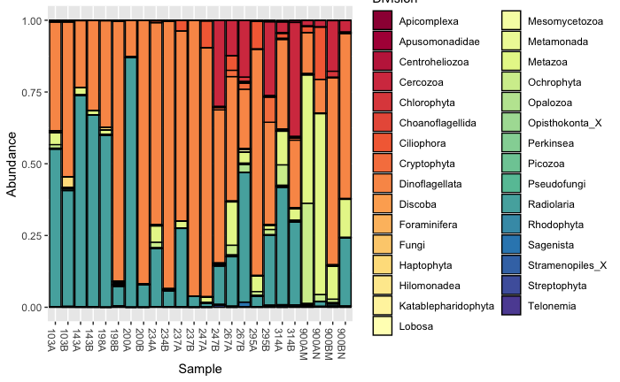

```r
# First aglomerate the ASVs at the phylum level using the phyloseq function, tax_glom
ps_ra_mean_division <- tax_glom(ps_ra_mean, "Division")


# and check by bar plotting
plot_bar(ps_ra_mean_division, x = "Sample", fill = "Division") +
  scale_fill_manual(values = DivisionPalette)
```

## Bubble Plots

### Prepare data

Extract mean relative abudnance, glommed by division, from the phyloseq object and pair it to taxonomic data

```r
division_df <- data.frame(otu_table(ps_ra_mean_division))
colnames(division_df) <- colnames(otu_table(ps_ra_mean_division))
division_df$ASV <- rownames(division_df)

otu_table_mean_ra <- left_join(division_df, as_tibble(taxonomy, rownames = "ASV"), by = "ASV")
otu_table_mean_ra
```

| 103A | 198A | 234A | 295A | 314A | 900AM | 103B | 198B | 234B | 295B | 314B | 900BM | 143A | 200A | 237A | 247A | 267A | 900AN | 143B | 200B | 237B | 247B | 267B | 900BN | ASV | Kingdom | Supergroup | Division | Class | Order | … |
| --- | --- | --- | --- | --- | --- | --- | --- | --- | --- | --- | --- | --- | --- | --- | --- | --- | --- | --- | --- | --- | --- | --- | --- | --- | --- | --- | --- | --- | --- | --- |
| 6.525076e-04 | 9.251122e-05 | 3.459018e-04 | 2.188080e-03 | 3.780293e-02 | 1.921711e-02 | 2.526418e-03 | 2.337959e-03 | 1.323891e-03 | 2.575435e-01 | 0.3973715167 | 0.1765215447 | 1.814059e-04 | 3.939593e-05 | 3.654972e-04 | 1.848374e-03 | 1.226363e-01 | 2.320140e-02 | 4.728791e-04 | 5.714612e-05 | 8.483503e-05 | 2.998158e-01 | 1.983134e-01 | 4.075375e-02 | ASV_2 | Eukaryota | Rhizaria | Cercozoa | Filosa-Thecofilosea | Cryomonadida | … |
| 3.786621e-01 | 3.714788e-01 | 7.035090e-01 | 7.880768e-01 | 3.126325e-01 | 1.434025e-01 | 5.399940e-01 | 9.046519e-01 | 9.318434e-01 | 3.567182e-01 | 0.2358692688 | 0.6524731061 | 2.323744e-01 | 1.261589e-01 | 6.623095e-01 | 8.673802e-01 | 4.338497e-01 | 1.185416e-01 | 3.133015e-01 | 9.185096e-01 | 9.601564e-01 | 5.338456e-01 | 2.077602e-01 | 5.752114e-01 | ASV_3 | Eukaryota | Alveolata | Dinoflagellata | Syndiniales | Dino-Group-I | … |
| 1.219852e-02 | 1.776215e-03 | 1.899445e-02 | 1.271500e-02 | 7.077856e-02 | 3.486181e-01 | 1.790943e-03 | 2.769449e-03 | 9.522590e-04 | 1.829528e-02 | 0.0040282509 | 0.0119688562 | 7.301207e-04 | 6.565988e-05 | 6.274884e-04 | 1.580094e-03 | 3.333507e-02 | 2.290895e-02 | 3.216721e-04 | 0.000000e+00 | 3.370398e-05 | 4.267318e-04 | 4.492984e-03 | 8.831468e-04 | ASV_6 | Eukaryota | Stramenopiles | Ochrophyta | Bacillariophyta | Bacillariophyta_X | … |
| 5.493408e-01 | 5.999445e-01 | 2.025452e-01 | 3.710778e-02 | 4.089338e-01 | 4.629494e-03 | 4.035581e-01 | 6.689517e-02 | 5.425381e-02 | 2.438469e-01 | 0.2890783715 | 0.0072952172 | 7.370889e-01 | 8.700197e-01 | 2.736641e-01 | 1.450012e-02 | 1.723744e-01 | 1.608501e-02 | 6.685024e-01 | 7.883308e-02 | 3.851812e-02 | 1.346062e-01 | 4.510495e-01 | 2.380130e-01 | ASV_10 | Eukaryota | Rhizaria | Radiolaria | Polycystinea | Spumellarida | … |
| 4.153304e-03 | 4.903095e-04 | 6.567853e-03 | 9.570775e-02 | 1.717277e-02 | 2.109431e-02 | 1.319927e-04 | 3.475467e-04 | 3.558482e-04 | 6.776308e-04 | 0.0010751908 | 0.0002952666 | 8.933101e-04 | 2.757715e-04 | 3.700066e-02 | 9.321144e-02 | 5.119455e-02 | 1.823942e-01 | 1.423529e-04 | 2.857306e-05 | 4.241752e-04 | 4.093644e-04 | 2.465381e-03 | 2.679209e-03 | ASV_14 | Eukaryota | Alveolata | Ciliophora | Nassophorea | Nassophorea_X | … |
| 4.228903e-02 | 1.452426e-02 | 5.776778e-02 | 5.543629e-02 | 1.176164e-01 | 4.485109e-01 | 3.717117e-04 | 4.724993e-03 | 1.018452e-03 | 1.515714e-02 | 0.0402484965 | 0.1153930812 | 2.565948e-02 | 9.717663e-04 | 2.405835e-02 | 1.908281e-02 | 1.512169e-01 | 6.309222e-01 | 1.388587e-02 | 5.714612e-05 | 2.993394e-04 | 5.359625e-03 | 3.820188e-02 | 1.326357e-01 | ASV_29 | Eukaryota | Opisthokonta | Metazoa | Cnidaria | Cnidaria_X | … |
| 5.354845e-05 | 9.251122e-06 | 1.085339e-04 | 1.287831e-03 | 3.865097e-03 | 2.192269e-04 | 1.919225e-04 | 3.624035e-04 | 8.873280e-05 | 8.756938e-02 | 0.0069250022 | 0.0005187861 | 0.000000e+00 | 0.000000e+00 | 8.230552e-05 | 6.148064e-04 | 2.160216e-02 | 0.000000e+00 | 5.648926e-05 | 0.000000e+00 | 3.775865e-05 | 8.499449e-03 | 2.075989e-02 | 9.922998e-05 | ASV_78 | Eukaryota | Hacrobia | Cryptophyta | Cryptophyceae | Cryptophyceae_X | … |
| 1.556079e-04 | 3.700449e-05 | 1.197277e-04 | 2.071753e-04 | 6.197201e-04 | 1.913030e-03 | 1.399232e-03 | 2.405594e-05 | 6.619267e-04 | 3.831412e-03 | 0.0046555629 | 0.0211584175 | 9.070295e-06 | 0.000000e+00 | 0.000000e+00 | 2.345230e-04 | 5.857906e-04 | 1.949698e-04 | 2.561445e-04 | 2.571576e-04 | 2.323609e-05 | 2.898700e-03 | 1.506878e-02 | 2.148329e-03 | ASV_148 | Eukaryota | Archaeplastida | Chlorophyta | Mamiellophyceae | Mamiellales | … |
| 6.200338e-03 | 9.954207e-03 | 4.017720e-03 | 2.310760e-04 | 3.261685e-05 | 1.215734e-03 | 3.605637e-02 | 2.407014e-03 | 2.137016e-03 | 1.067063e-03 | 0.0011595857 | 0.0017267044 | 4.302692e-05 | 1.864741e-03 | 1.935696e-05 | 0.000000e+00 | 0.000000e+00 | 0.000000e+00 | 9.378969e-04 | 8.000457e-04 | 8.083863e-05 | 1.952096e-05 | 7.142693e-04 | 5.556879e-04 | ASV_160 | Eukaryota | Hacrobia | Haptophyta | Prymnesiophyceae | Phaeocystales | … |
| 1.043834e-03 | 3.700449e-05 | 1.406873e-03 | 5.030634e-04 | 3.343227e-03 | 2.863571e-03 | 2.143546e-03 | 4.146467e-03 | 1.849313e-03 | 2.109671e-03 | 0.0051396264 | 0.0027166221 | 9.433107e-04 | 2.626395e-05 | 8.206933e-04 | 3.238836e-04 | 3.194781e-03 | 1.169819e-03 | 8.420965e-04 | 5.714612e-05 | 1.975068e-04 | 1.888213e-03 | 1.675077e-02 | 2.222751e-03 | ASV_249 | Eukaryota | Stramenopiles | Sagenista | MAST-20 | MAST-20_X | … |

[output cut: 21 more lines]

Pivot longer

```r
otu_table_mean_ra <- pivot_longer(otu_table_mean_ra, cols = unique(metadata$Replicate), names_to = "Replicate", values_to = "Mean_RA")
otu_table_mean_ra
```

| ASV | Kingdom | Supergroup | Division | Class | Order | Family | Genus | Species | Replicate | Mean_RA |
| --- | --- | --- | --- | --- | --- | --- | --- | --- | --- | --- |
| ASV_2 | Eukaryota | Rhizaria | Cercozoa | Filosa-Thecofilosea | Cryomonadida | Cryomonadida_X | Cercozoa-01 | Cercozoa-01_sp. | 103A | 6.525076e-04 |
| ASV_2 | Eukaryota | Rhizaria | Cercozoa | Filosa-Thecofilosea | Cryomonadida | Cryomonadida_X | Cercozoa-01 | Cercozoa-01_sp. | 198A | 9.251122e-05 |
| ASV_2 | Eukaryota | Rhizaria | Cercozoa | Filosa-Thecofilosea | Cryomonadida | Cryomonadida_X | Cercozoa-01 | Cercozoa-01_sp. | 234A | 3.459018e-04 |
| ASV_2 | Eukaryota | Rhizaria | Cercozoa | Filosa-Thecofilosea | Cryomonadida | Cryomonadida_X | Cercozoa-01 | Cercozoa-01_sp. | 295A | 2.188080e-03 |
| ASV_2 | Eukaryota | Rhizaria | Cercozoa | Filosa-Thecofilosea | Cryomonadida | Cryomonadida_X | Cercozoa-01 | Cercozoa-01_sp. | 314A | 3.780293e-02 |
| ASV_2 | Eukaryota | Rhizaria | Cercozoa | Filosa-Thecofilosea | Cryomonadida | Cryomonadida_X | Cercozoa-01 | Cercozoa-01_sp. | 900AM | 1.921711e-02 |
| ASV_2 | Eukaryota | Rhizaria | Cercozoa | Filosa-Thecofilosea | Cryomonadida | Cryomonadida_X | Cercozoa-01 | Cercozoa-01_sp. | 103B | 2.526418e-03 |
| ASV_2 | Eukaryota | Rhizaria | Cercozoa | Filosa-Thecofilosea | Cryomonadida | Cryomonadida_X | Cercozoa-01 | Cercozoa-01_sp. | 198B | 2.337959e-03 |
| ASV_2 | Eukaryota | Rhizaria | Cercozoa | Filosa-Thecofilosea | Cryomonadida | Cryomonadida_X | Cercozoa-01 | Cercozoa-01_sp. | 234B | 1.323891e-03 |
| ASV_2 | Eukaryota | Rhizaria | Cercozoa | Filosa-Thecofilosea | Cryomonadida | Cryomonadida_X | Cercozoa-01 | Cercozoa-01_sp. | 295B | 2.575435e-01 |

[output cut: 734 more lines]

Join metadata

```r
otu_table_mean_ra <- left_join(otu_table_mean_ra, unique(select(metadata, c("Replicate", "Depth", "SizeFraction", "Season", "OxCond", "Fluorescence", "BeamAtt", "O2", "Temp", "Salinity", "H2S", "ParticulateS", "TZVS", "CH4", "NO3", "NO2", "NH4", "PO4", "Chemoautotrophy", "BNP", "MicroAbun(x10^8 L^-1)", "FlagAbun(x10^5 L-1)", "VLP(x10^8 L-1)"))), by = "Replicate")

# Replace zeroes in RA with NA (better for plotting)
otu_table_mean_ra$Mean_RA[otu_table_mean_ra$Mean_RA == 0] <- NA


otu_table_mean_ra
```

| ASV | Kingdom | Supergroup | Division | Class | Order | Family | Genus | Species | Replicate | Mean_RA | Depth | SizeFraction | Season | OxCond | Fluorescence | BeamAtt | O2 | Temp | Salinity | H2S | ParticulateS | TZVS | CH4 | NO3 | NO2 | NH4 | PO4 | Chemoautotrophy | BNP | … |
| --- | --- | --- | --- | --- | --- | --- | --- | --- | --- | --- | --- | --- | --- | --- | --- | --- | --- | --- | --- | --- | --- | --- | --- | --- | --- | --- | --- | --- | --- | --- |
| ASV_2 | Eukaryota | Rhizaria | Cercozoa | Filosa-Thecofilosea | Cryomonadida | Cryomonadida_X | Cercozoa-01 | Cercozoa-01_sp. | 103A | 6.525076e-04 | 103 | PA | May | Oxycline | 0.0509 | 0.0911 | 122.90 | 19.70 | 36.70 | 0.00 | 0.00 | 0.00 | 0.02 | 8.84 | 0.15 | 0.39 | 0.54 | 0.33 | 1.36 | … |
| ASV_2 | Eukaryota | Rhizaria | Cercozoa | Filosa-Thecofilosea | Cryomonadida | Cryomonadida_X | Cercozoa-01 | Cercozoa-01_sp. | 198A | 9.251122e-05 | 198 | PA | May | Oxycline | -0.0123 | 0.1249 | 31.90 | 18.10 | 36.40 | 0.00 | 0.00 | 0.00 | 0.02 | 10.97 | 0.03 | 0.58 | 1.53 | 0.78 | 0.45 | … |
| ASV_2 | Eukaryota | Rhizaria | Cercozoa | Filosa-Thecofilosea | Cryomonadida | Cryomonadida_X | Cercozoa-01 | Cercozoa-01_sp. | 234A | 3.459018e-04 | 234 | PA | May | Oxycline | -0.0087 | 0.0492 | 12.00 | 17.90 | 36.40 | 0.00 | 0.03 | 0.02 | 0.08 | 8.85 | 0.02 | 0.43 | 1.81 | 0.36 | 0.46 | … |
| ASV_2 | Eukaryota | Rhizaria | Cercozoa | Filosa-Thecofilosea | Cryomonadida | Cryomonadida_X | Cercozoa-01 | Cercozoa-01_sp. | 295A | 2.188080e-03 | 295 | PA | May | ShallowAnoxic | -0.0005 | 0.0767 | 0.00 | 17.70 | 36.40 | 0.00 | 0.14 | 0.22 | 0.81 | 0.40 | 0.01 | 2.01 | 2.49 | 6.52 | 1.76 | … |
| ASV_2 | Eukaryota | Rhizaria | Cercozoa | Filosa-Thecofilosea | Cryomonadida | Cryomonadida_X | Cercozoa-01 | Cercozoa-01_sp. | 314A | 3.780293e-02 | 314 | PA | May | ShallowAnoxic | 0.0362 | 0.0485 | 0.00 | 17.60 | 36.40 | 6.76 | 0.46 | 0.20 | 1.75 | 0.02 | 0.00 | 4.56 | 2.97 | 12.12 | 1.35 | … |
| ASV_2 | Eukaryota | Rhizaria | Cercozoa | Filosa-Thecofilosea | Cryomonadida | Cryomonadida_X | Cercozoa-01 | Cercozoa-01_sp. | 900AM | 1.921711e-02 | 900 | PA | May | Euxinic | 0.0349 | 0.0412 | 0.00 | 17.10 | 36.30 | 70.33 | 0.00 | 0.00 | 12.42 | 0.12 | 0.01 | 23.65 | 3.96 | 0.00 | 0.08 | … |
| ASV_2 | Eukaryota | Rhizaria | Cercozoa | Filosa-Thecofilosea | Cryomonadida | Cryomonadida_X | Cercozoa-01 | Cercozoa-01_sp. | 103B | 2.526418e-03 | 103 | FL | May | Oxycline | 0.0509 | 0.0911 | 122.90 | 19.70 | 36.70 | 0.00 | 0.00 | 0.00 | 0.02 | 8.84 | 0.15 | 0.39 | 0.54 | 0.33 | 1.36 | … |
| ASV_2 | Eukaryota | Rhizaria | Cercozoa | Filosa-Thecofilosea | Cryomonadida | Cryomonadida_X | Cercozoa-01 | Cercozoa-01_sp. | 198B | 2.337959e-03 | 198 | FL | May | Oxycline | -0.0123 | 0.1249 | 31.90 | 18.10 | 36.40 | 0.00 | 0.00 | 0.00 | 0.02 | 10.97 | 0.03 | 0.58 | 1.53 | 0.78 | 0.45 | … |
| ASV_2 | Eukaryota | Rhizaria | Cercozoa | Filosa-Thecofilosea | Cryomonadida | Cryomonadida_X | Cercozoa-01 | Cercozoa-01_sp. | 234B | 1.323891e-03 | 234 | FL | May | Oxycline | -0.0087 | 0.0492 | 12.00 | 17.90 | 36.40 | 0.00 | 0.03 | 0.02 | 0.08 | 8.85 | 0.02 | 0.43 | 1.81 | 0.36 | 0.46 | … |
| ASV_2 | Eukaryota | Rhizaria | Cercozoa | Filosa-Thecofilosea | Cryomonadida | Cryomonadida_X | Cercozoa-01 | Cercozoa-01_sp. | 295B | 2.575435e-01 | 295 | FL | May | ShallowAnoxic | -0.0005 | 0.0767 | 0.00 | 17.70 | 36.40 | 0.00 | 0.14 | 0.22 | 0.81 | 0.40 | 0.01 | 2.01 | 2.49 | 6.52 | 1.76 | … |

[output cut: 734 more lines]

### Plot

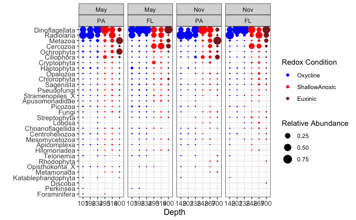

Save plot

```r
ggsave(filename = "Figures/euk_divisions_bubbleplot_color.eps", plot = euk_divisions_bubbleplot_color, units = c("in"), width = 10, height = 6, dpi = 300)
```

# ALL BELOW IS FROM ANOTHER NOTEBOOK. NEEDS MODIFICATION

## Ordinations

### First, more filtering

Need to constrain the size of the count tables more, otherwise the matrix algebra during ordinations overwhelems R.

McMurdie and Holmes (2013) filter out taxa that were not seen with more than 3 counts in at least 20% of the samples. We also want to add a pseduocount of 1 to all counts. This is so that later when we do different calculations (log, division, etc) we don’t get back errors due to zeroes

```r
ps_filtered = filter_taxa(ps, function(x) sum(x > 3) > (0.2*length(x)), TRUE)
ps_filtered <- transform_sample_counts(ps_filtered, function(x) x+1)

# Also make a filtered version of the relative abundance count table (for plotting purposes)
ps_ra_filtered <- prune_taxa(taxa_names(ps_filtered),ps_ra) # prune from ps_ra object (relative abundances)

# check number of ASVs in each
ps
ps_filtered
ps_ra_filtered
```

Check remaining phyla

```r
table(tax_table(ps_filtered)[, "phylum"], exclude = NULL)
```

Check by plotting phyla again

```r
# There are many phyla here, so have to make a custom color palette by interpolating from an existing one in RColorBrewer
colourCount = length(table(tax_table(ps_ra_filtered)[, "phylum"], exclude = NULL))
getPalette = colorRampPalette(brewer.pal(11, "Spectral"))
PhylaFilteredPalette = getPalette(colourCount)

phylum_filtered_Glommed_RA = tax_glom(ps_ra_filtered, "phylum")
# and plot
phyla_barplot_filtered <- plot_bar(phylum_filtered_Glommed_RA, x = "Sample", fill = "phylum") +
  scale_fill_manual(values = PhylaFilteredPalette) +
  theme(legend.text = element_text(size = 10))

phyla_barplot_filtered

# export
ggsave("figures/phyla_barplot_filtered.eps",phyla_barplot_filtered, width = 15, height = 5, units = c("in"))
```

Lastly, reroot-the tree affiliated with the ps_filtered and ps_ra_filtered dataset, since the root may have been removed when filtering

```r
# first define function from link above to find furthest outgroup
pick_new_outgroup <- function(tree.unrooted){
require("magrittr")
require("data.table")
require("ape") # ape::Ntip
# tablify parts of tree that we need.
treeDT <-
     cbind(
         data.table(tree.unrooted$edge),
         data.table(length = tree.unrooted$edge.length)
     )[1:Ntip(tree.unrooted)] %>%
 cbind(data.table(id = tree.unrooted$tip.label))
 # Take the longest terminal branch as outgroup
 new.outgroup <- treeDT[which.max(length)]$id
 return(new.outgroup) }

# then run on my phyloseq tree
my.tree <- phy_tree(ps_filtered)
out.group <- pick_new_outgroup(my.tree)
out.group

# Then use this outgroup to root the tree
new.tree1 <- ape::root(my.tree, outgroup=out.group, resolve.root=TRUE)


phy_tree(ps_filtered) <- new.tree1
phy_tree(ps_ra_filtered) <- new.tree1

# Check if tree is binary (not multichotomous)
is.binary.tree(phy_tree(ps_filtered))
```

Now move onto ordinations using this filtered dataset

### Test for compositionality

based on Coenen et al. tutorials for clustering. See [repo](https://github.com/WeitzGroup/analyzing_microbiome_timeseries)

```r
# Estimate covariance matrix for OTUs
covariance_matrix <- as.matrix(otu_table(ps_filtered)) %*% t(otu_table(ps_filtered))
# %*% = matrix multiplication sign in R; used here to multiply OTU/ASV data matrix to itself to estimate covariance.

# Evaluate determinant of covariance matrix
cov_determinant <- det(covariance_matrix)
cov_determinant
```

The determinant of the covariance matrix (what we just calculated) is equivalent to the product of the proportion of variance explained by every PCA axis. If the determinant is 0, that means there is an axis which explains 0 variance that we can’t separate from the other axes. This means the data need to be transformed to be suitable for PCA.

### PCA

PCA is essentially a type of PCoA using the Euclidean distance matrix as input. When combined with a log-ratio transformation of the count table, this is deemed appropriate for *compositional* datasets.

First do a **CLR, centered log ratio** transformation of the absolute abundance data (after filtering), as suggested by [Gloor et al. 2017](https://www.frontiersin.org/articles/10.3389/fmicb.2017.02224/full) and check the determinant of this matrix. Compare it to the determinant without any transformation. {Also commented out for now because takes a few minutes}

```r
# Estimate covariance matrix for absolute abundance ASV table
covariance_matrix <- as.matrix(otu_table(ps_filtered)) %*% t(otu_table(ps_filtered))
# %*% = matrix multiplication sign in R; used here to multiply OTU/ASV data matrix to itself to estimate covariance.

# Evaluate determinant of covariance matrix
cov_determinant <- det(covariance_matrix)

# Estimate covariance matrix for CLR-transformed ASV table
clr_asv_table_ps_filtered <- data.frame(compositions::clr(t(otu_table(ps_filtered))))

## Check new determinant of clr transformed table
new_covdet <- det(as.matrix(clr_asv_table_ps_filtered) %*% t(clr_asv_table_ps_filtered))

# Compare
cov_determinant #Original Count Data
new_covdet # New
```

The determinant of a covariance matrix = the product of the proportion of variance explained by every PCA axis. If one axis is zero, the product (determinant) is 0, and we can’t separate that axis from the other axes. Thus, these data require transformation in order to be suitable for ordinations. The determinant of the CLR-transformed table is not zero, so we can proceed with PCA of the CLR-transformed data.

Generate the PCA and visualize axes

```r
# Generate a Principle Component Analysis (PCA) and evaluated based on the eigen decomposition from sample covariance matrix.
lograt_pca <- prcomp(clr_asv_table_ps_filtered)
# NOTE- this is equivalent to first making a Euclidean distance matrix using the CLR data table and then running a PCoA. A Euclidean distance matrix of a log-transformed data table = an Aitchison distance matrix. So this is equivalent to the compositional methods listed in Gloor et al.

# Visual representation with a screeplot
lograt_variances <- as.data.frame(lograt_pca$sdev^2/sum(lograt_pca$sdev^2)) %>% #Extract axes
  # Format to plot
  select(PercVar = 'lograt_pca$sdev^2/sum(lograt_pca$sdev^2)') %>%
  rownames_to_column(var = "PCaxis") %>%
  data.frame
head(lograt_variances)

# Plot screeplot
ggplot(lograt_variances, aes(x = as.numeric(PCaxis), y = PercVar)) +
  geom_bar(stat = "identity", fill = "grey", color = "black") +
  theme_minimal() +
  theme(axis.title = element_text(color = "black", face = "bold", size = 10),
        axis.text.y = element_text(color = "black", face = "bold"),
        axis.text.x = element_blank()) +
  labs(x = "PC axis", y = "% Variance", title = "Log-Ratio PCA Screeplot, CLR Tranformation")
```

A faithful representation is to plot this ordination in 2D because the 3rd and 4th axes appear very similar, while the 1st and 2nd explain a decently large proportion of variance (23.8 + 19.7 = 43.5%)

Visualize the PCA

```r
# lograt_pca$x #View PC values
pca_lograt_frame <- data.frame(lograt_pca$x) %>%
  rownames_to_column(var = "#SampleID")

# Merge metadata into the pca data table
pca_lograt_frame <- left_join(pca_lograt_frame, metadata, by = "#SampleID")
head(pca_lograt_frame)


# Plot PCA with Salinity
pca_lograt_salinity <- ggplot(pca_lograt_frame, aes(x = PC1, y = PC2)) +
  geom_point(aes(color = Salinity, shape = Size_fraction), size = 4) +
  geom_text(aes(label = `#SampleID`), size = 3, hjust = 0, vjust = 0) +
  ylab(paste0('PC2 ', round(lograt_variances[2,2]*100,2),'%')) + #Extract y axis value from variance
  xlab(paste0('PC1 ', round(lograt_variances[1,2]*100,2),'%')) + #Extract x axis value from variance
  scale_color_distiller(palette = "Spectral", direction = 1, limits = c(min(sample_data(ps_filtered)$Salinity), max(sample_data(ps_filtered)$Salinity)), name = 'Salinity') +
  ggtitle('CLR-Euclidean PCA') +
  coord_fixed(ratio = 1) +
  theme_bw()

pca_lograt_salinity

ggsave("figures/pca_lograt_salinity.eps",pca_lograt_salinity, width = 7, height = 5, units = c("in"))

# Plot PCA with Temperature
pca_lograt_temp <- ggplot(pca_lograt_frame, aes(x = PC1, y = PC2)) +
  geom_point(aes(color = Temperature, shape = Size_fraction), size = 4) +
  geom_text(aes(label = `#SampleID`), size = 3, hjust = 0, vjust = 0) +
  ylab(paste0('PC2 ', round(lograt_variances[2,2]*100,2),'%')) + #Extract y axis value from variance
  xlab(paste0('PC1 ', round(lograt_variances[1,2]*100,2),'%')) + #Extract x axis value from variance
  scale_color_distiller(palette = "Spectral", direction = 1, limits = c(min(sample_data(ps_filtered)$Temperature), max(sample_data(ps_filtered)$Temperature)), name = 'Temperature') +
  ggtitle('CLR-Euclidean PCA') +
  coord_fixed(ratio = 1) +
  theme_bw()

pca_lograt_temp

ggsave("figures/pca_lograt_temp.eps",pca_lograt_temp, width = 7, height = 5, units = c("in"))
```

The CLR-Euclidean PCA reveals a separation among samples driven in part by salinity and temperature, except for samples N1 and N2 (all the way on the bottom left) which cluster differently. The samples from the same location and different size fractions are similar in most cases. (Eg. R1/R2 are close to G1/2, etc)

### PhILR

The compositional approach to ordinations that takes into account phylogenetic relatedness is **PhILR**, which uses the ILR transformation and calculates a weighted abundance (“balance”). It also scales the balances by phylogenetic distances, therefore taking into account phylogenetic relatedness (similar to Unifrac).

Based this on the Silverman et al. [tutorial](https://bioconductor.org/packages/release/bioc/vignettes/philr/inst/doc/philr-intro.html).

Prepare the data and load the philr package. (Note: I did not load this this earlier because there is an incompatibility with phyloseq and one of the philr dependencies and it spits out a warning every time I ran anything in phyloseq. I wanted to limit that printing out in the markdown file. The red text can be ignored).

```r
# Make node labels in tree: n1, n2, etc.
phy_tree(ps_filtered) <- makeNodeLabel(phy_tree(ps_filtered), method="number", prefix='n')

# Load philr
library(philr)

# Name the balances (see Fig. 1 from Silverman et al. for depiction of "balance")
name.balance(phy_tree(ps_filtered), tax_table(ps_filtered), 'n1')
```

Extract the individual components from the phyloseq object and take a look

```r
otu.table2 <- t(otu_table(ps_filtered))
tree2 <- phy_tree(ps_filtered)
metadata2 <- sample_data(ps_filtered)
tax2 <- tax_table(ps_filtered)

otu.table2[1:5,1:5] # ASV Table
tree2 # Phylogenetic Tree
head(metadata2,2) # Metadata
head(tax2,5) # taxonomy table
```

Next, pass the otu table, etc into PhILR, which will convert the tree to a sequential binary partition representation, calculate the weights of the taxa, build the contrast matrix, convert the OTU table to relative abundance (NOTE: you should pass absolute abundances into this function because it calculates the RA within it), transform using the phylogenetic-ILR transformation, and weigh by phylogenetic distances

```r
ps.philr <- philr(otu.table2, tree2,
                  part.weights='enorm.x.gm.counts',
                  ilr.weights='blw.sqrt')
```

Check output

```r
ps.philr[1:5,1:5]
```

Now the “OTU table” is presented with samples as rows and balances as columns. Each balance is associated with a node of the tree, n1, n2, etc.

Next do the ordination using a Euclidean distance matrix and check the screeplot

```r
ps.philr.dist.euc <- dist(ps.philr, method="euclidean")
ps.philr.pcoa <- ordinate(ps_filtered, 'PCoA', distance=ps.philr.dist.euc)

# Extract variances from pcoa, from jaccard calculated dist. metric
philr_variances <- data.frame(ps.philr.pcoa$values$Relative_eig) %>%
  select(PercVar = 'ps.philr.pcoa.values.Relative_eig') %>%
  rownames_to_column(var = "PCaxis") %>%
  data.frame
head(philr_variances)

# Make a screeplot
ggplot(philr_variances, aes(x = as.numeric(PCaxis), y = PercVar)) +
  geom_bar(stat = "identity", fill = "grey", color = "black") +
  theme_minimal() +
  theme(axis.title = element_text(color = "black", face = "bold", size = 10),
        axis.text.y = element_text(color = "black", face = "bold"),
        axis.text.x = element_blank()) +
  labs(x = "PC axis", y = "% Variance", title = "PhILR PCoA Screeplot")
```

Based on above, it’s fair to plot the first two axes. This would be 39.1+19.8 = 58.9% total variance

Plot the ordination using phyloseq syntax

```r
# Plot  with salinity
ps.philr.pcoa.plot.salinity <- plot_ordination(ps_filtered, ps.philr.pcoa, shape="Size_fraction", color='Salinity') +   geom_point(size = 4) +
  scale_color_distiller(palette = "Spectral", direction = 1, limits = c(min(sample_data(ps_filtered)$Salinity), max(sample_data(ps_filtered)$Salinity)), name = 'Salinity') +
  geom_text(aes(label = X.SampleID), size = 3, hjust = 0, vjust = 0, , color = "black") +
  ggtitle('PhILR PCoA Ordination') +
  coord_fixed(ratio = 1) +
  theme_bw()

ps.philr.pcoa.plot.salinity

ggsave("figures/ps.philr.pcoa.plot.salinity.eps",ps.philr.pcoa.plot.salinity, width = 7, height = 5, units = c("in"))

# Plot with Temperature
ps.philr.pcoa.plot.temp <- plot_ordination(ps_filtered, ps.philr.pcoa, shape="Size_fraction", color='Temperature') +   geom_point(size = 4) +
  scale_color_distiller(palette = "Spectral", direction = 1, limits = c(min(sample_data(ps_filtered)$Temperature), max(sample_data(ps_filtered)$Temperature)), name = 'Temperature') +
  geom_text(aes(label = X.SampleID), size = 3, hjust = 0, vjust = 0, , color = "black") +
  ggtitle('PhILR PCoA Ordination') +
  coord_fixed(ratio = 1) +
  theme_bw()

ps.philr.pcoa.plot.temp

ggsave("figures/ps.philr.pcoa.plot.temp.eps",ps.philr.pcoa.plot.temp, width = 7, height = 5, units = c("in"))
```

The plot above is very similar to the PCA with a minor difference: there is more distance separation among the PA/Fl samples along axis 1. Because this ordination is weighted by phylogenetic relatedness, this means that differences between PA and FL are driven by abundances of taxa that are phylogenetically distinct (ie. not closely related)

### PCoA

The more traditional approach to ordinations is to do a PCoA on a distance matrix such as Bray-Curtis, Jaccard, or Unifrac. While these are not considered compositional approaches, when combined with pre-treatment (transformations) they become more appropriate. One such transformation that I will use here is the Hellinger transformation.

The different distance matrices also tell you a few different things about the dataset so I will run through this to try to see if I can tease those out.

Before calculating any distance matrix, do a transformation of the filtered count table. Hellinger transformation is the square root of the relative abundance, so calculate it based on the ps_ra_filtered object:

```r
ps_hellinger <- transform_sample_counts(ps_ra_filtered, function(x){sqrt(x)})
```

First, **Jaccard**, which builds the distance matrix based on presence/absence between samples. It does not take into account relative abundance of the taxa. Therefore this functions well for determining differences driven by rare taxa, which are weighed the same as abundant taxa.

```r
jac_dmat<-vegdist(t(otu_table(ps_hellinger)),method="jaccard") # Jaccard dist metric
pcoa_jac<-pcoa(jac_dmat) # perform PCoA

# Extract variances from pcoa, from jaccard calculated dist. metric
jac_variances <- data.frame(pcoa_jac$values$Relative_eig) %>%
  select(PercVar = 'pcoa_jac.values.Relative_eig') %>%
  rownames_to_column(var = "PCaxis") %>%
  data.frame
head(jac_variances)

# Make a screeplot
ggplot(jac_variances, aes(x = as.numeric(PCaxis), y = PercVar)) +
  geom_bar(stat = "identity", fill = "grey", color = "black") +
  theme_minimal() +
  theme(axis.title = element_text(color = "black", face = "bold", size = 10),
        axis.text.y = element_text(color = "black", face = "bold"),
        axis.text.x = element_blank()) +
  labs(x = "PC axis", y = "% Variance", title = "Jaccard PCoA Screeplot")
```

The first two axes (22.5 + 17.1 = 39.6%) pretty good. But I am going to experiment and plot the first 3 axes since the 2nd and 3rd explain a similar amount of variance, 17.1 and 11.3% respectively

Plot in 3D with Plotly

```r
# Extract variances from the jaccard pcoa
pcoa_jac_df <- data.frame(pcoa_jac$vectors) %>%
  rownames_to_column(var = "#SampleID")

# Merge metadata into the pcoa data table
pcoa_jac_df <- left_join(pcoa_jac_df, metadata, by = "#SampleID")
head(pcoa_jac_df)

# Select eigenvalues from dataframe, round to 4 places and multiply by 100 for plotting. These will be the axes for the 3-D plot
eigenvalues<-round(jac_variances[,2], digits = 4)*100

# Plotly - 3-D
pcoa_jaccard <- plot_ly(pcoa_jac_df, type='scatter3d', mode='markers',
        x=~Axis.2,y=~Axis.3,z=~Axis.1,colors=~brewer.pal(11,'Spectral'),
        color=~Salinity, symbols = c('circle','diamond-open'), symbol=~Size_fraction)%>%
  layout(font=list(size=12),
         title='PCoA Jaccard Distance',
         scene=list(xaxis=list(title=paste0('Co 2 ',eigenvalues[2],'%'),
                               showticklabels=FALSE,zerolinecolor='black'),
                    yaxis=list(title=paste0('Co 3 ',eigenvalues[3],'%'),
                               showticklabels=FALSE,zerolinecolor='black'),
                    zaxis=list(title=paste0('Co 1 ',eigenvalues[1],'%'),
                               showticklabels=FALSE,zerolinecolor='black')))
pcoa_jaccard

withr::with_dir('Figures', htmlwidgets::saveWidget(as_widget(pcoa_jaccard), file="pcoa_jaccard.html"))
```

The Jaccard-PCoA is still driven by differences in salinity/temperature. Similar to the PCA and PhILR results, there are a couple of samples (green diamonds) that are clustering away from that pattern along PC1. There is some slight separation of Total/Pfree pairs in most cases.

Next, try a **Bray-Curtis** distance matrix with PCoA, which builds the distance matrix based on presence/absence between samples *and* relative abundance differences. This ordination will represent well the differences in samples that are driven by taxa with high relative abundances.

```r
bray_dmat<-vegdist(t(otu_table(ps_hellinger)),method="bray") # Bray-Curtis dist metric
pcoa_bray<-pcoa(bray_dmat) # perform PCoA

# Extract variances from pcoa, from jaccard calculated dist. metric
bray_variances <- data.frame(pcoa_bray$values$Relative_eig) %>%
  select(PercVar = 'pcoa_bray.values.Relative_eig') %>%
  rownames_to_column(var = "PCaxis") %>%
  data.frame
head(bray_variances)

# Make a screeplot
ggplot(bray_variances, aes(x = as.numeric(PCaxis), y = PercVar)) +
  geom_bar(stat = "identity", fill = "grey", color = "black") +
  theme_minimal() +
  theme(axis.title = element_text(color = "black", face = "bold", size = 10),
        axis.text.y = element_text(color = "black", face = "bold"),
        axis.text.x = element_blank()) +
  labs(x = "PC axis", y = "% Variance", title = "Bray-Curtis PCoA Screeplot")
```

The first two axes (32.6 + 21.9 = 54.5%) are pretty good again but I am still going to experiment in the plot with the 3rd axis (12.6% variance)

Plot in 3D with Plotly

```r
# Extract variances from the jaccard pcoa
pcoa_bray_df <- data.frame(pcoa_bray$vectors) %>%
  rownames_to_column(var = "#SampleID")

# Merge metadata into the pcoa data table
pcoa_bray_df <- left_join(pcoa_bray_df, metadata, by = "#SampleID")
head(pcoa_bray_df)

# Select eigenvalues from dataframe, round to 4 places and multiply by 100 for plotting. These will be the axes for the 3-D plot
eigenvalues<-round(bray_variances[,2], digits = 4)*100

# Plotly - 3-D
pcoa_bray <- plot_ly(pcoa_bray_df, type='scatter3d', mode='markers',
        x=~Axis.2,y=~Axis.3,z=~Axis.1,colors=~brewer.pal(11,'Spectral'),
        color=~Salinity, symbols = c('circle','diamond-open'), symbol=~Size_fraction)%>%
  layout(font=list(size=12),
         title='PCoA Bray-Curtis Distance',
         scene=list(xaxis=list(title=paste0('Co 2 ',eigenvalues[2],'%'),
                               showticklabels=FALSE,zerolinecolor='black'),
                    yaxis=list(title=paste0('Co 3 ',eigenvalues[3],'%'),
                               showticklabels=FALSE,zerolinecolor='black'),
                    zaxis=list(title=paste0('Co 1 ',eigenvalues[1],'%'),
                               showticklabels=FALSE,zerolinecolor='black')))
pcoa_bray

withr::with_dir('Figures', htmlwidgets::saveWidget(as_widget(pcoa_bray), file="pcoa_bray.html"))
```

These results are almost identical to those from the Jaccard, so the influence of abundant and rare taxa on differences among samples seems to be the same. This is maybe not surprising since I did filter out many of the very low abundant taxa in order to do the ordinations.

Next try a **Weighted Unifrac** distance matrix with PCoA. Unifrac prioritizes differences in relatedness (of taxa) among sample. Using weighted unifrac means we are also taking into account changes in relative abundance between samples.

This should be done with the phyloseq function, ordinate, which has a unifrac distance method. vegdist does not.

```r
out.wuf.log <- ordinate(ps_hellinger, method = "PCoA", distance = "wunifrac")
evals <- out.wuf.log$values$Eigenvalues

# Extract variances from pcoa, from jaccard calculated dist. metric
wuf_variances <- data.frame(out.wuf.log$values$Relative_eig) %>%
  select(PercVar = 'out.wuf.log.values.Relative_eig') %>%
  rownames_to_column(var = "PCaxis") %>%
  data.frame
head(wuf_variances)

# Make a screeplot
ggplot(wuf_variances, aes(x = as.numeric(PCaxis), y = PercVar)) +
  geom_bar(stat = "identity", fill = "grey", color = "black") +
  theme_minimal() +
  theme(axis.title = element_text(color = "black", face = "bold", size = 10),
        axis.text.y = element_text(color = "black", face = "bold"),
        axis.text.x = element_blank()) +
  labs(x = "PC axis", y = "% Variance", title = "Weighted Unifrac PCoA Screeplot")
```

The first two axes (31.3 + 25.7 = 57%) explain a lot of variance so this can be plotted with the first 2 axes. There are negative eigenvalues towards the end of this screeplot. But since these eigenvalues are small relative to the primary axes, they can be ignored.

Visualize in 2D

```r
pcoa_wuf <- plot_ordination(ps_hellinger, out.wuf.log, shape="Size_fraction", color = "Salinity") +
  geom_point(size = 4) +
  scale_color_distiller(palette = "Spectral", direction = 1, limits = c(min(sample_data(ps_hellinger)$Salinity), max(sample_data(ps_hellinger)$Salinity)), name = 'Salinity') +
  ggtitle('Weighted Unifrac PCoA Ordination') +
  coord_fixed(ratio = 1) +
  theme_bw()

pcoa_wuf

ggsave("figures/pcoa_wuf.eps",pcoa_wuf, width = 7, height = 5, units = c("in"))
```

There are very similar patterns here compared to the PCA and PhILR plots. I wonder if there is difference among Pfree/Total if we use an unweighted unifrac.

Next try a **Unweighted Unifrac** distance matrix with PCoA. Unifrac prioritizes differences in relatedness (of taxa) among sample. Using unweighted unifrac means we are weighing all taxa the same, no matter their relative abundance.

```r
out.uf.log <- ordinate(ps_hellinger, method = "PCoA", distance = "unifrac")
evals <- out.uf.log$values$Eigenvalues

# Extract variances from pcoa, from jaccard calculated dist. metric
uf_variances <- data.frame(out.uf.log$values$Relative_eig) %>%
  select(PercVar = 'out.uf.log.values.Relative_eig') %>%
  rownames_to_column(var = "PCaxis") %>%
  data.frame
head(uf_variances)

# Make a screeplot
ggplot(uf_variances, aes(x = as.numeric(PCaxis), y = PercVar)) +
  geom_bar(stat = "identity", fill = "grey", color = "black") +
  theme_minimal() +
  theme(axis.title = element_text(color = "black", face = "bold", size = 10),
        axis.text.y = element_text(color = "black", face = "bold"),
        axis.text.x = element_blank()) +
  labs(x = "PC axis", y = "% Variance", title = "Unweighted Unifrac PCoA Screeplot")
```

Visualize in 2D

```r
pcoa_uf <- plot_ordination(ps_hellinger, out.uf.log, shape="Size_fraction", color = "Salinity") +
  geom_point(size = 4) +
  scale_color_distiller(palette = "Spectral", direction = 1, limits = c(min(sample_data(ps_hellinger)$Salinity), max(sample_data(ps_hellinger)$Salinity)), name = 'Salinity') +
  ggtitle('Unweighted Unifrac PCoA Ordination') +
  coord_fixed(ratio = 1) +
  theme_bw()

pcoa_uf

ggsave("figures/pcoa_uf.eps",pcoa_uf, width = 7, height = 5, units = c("in"))
```

When you compare the unweighted to the weighted unifrac PCoA, there is some more distance between the Pfree vs Total samples in the UF, indicating that the differences between these samples is driven by taxa that are phylogenetically different, whether they are abundant or rare.

### NMDS

Lastly, try a non-metric dimensional scaling ordination. PCA/PCoA are metric and attempt to rotate axes to fit the distance matrix distribution. An NMDS represents the data in 2-axes, by constraining the distribution of the points. Similar to above, this can be combined with different pre-treatment of the data.

First try the compositional approach, an **NMDS on CLR-tranformed data using the Euclidean distances** (aka Aitchison distance)

```r
euc_dmat<-dist(clr_asv_table_ps_filtered, method = "euclidean") # Build the Aitchison distance matrix
euc_nmds <- metaMDS(euc_dmat, k=2, autotransform=FALSE) # Run the ordination
euc_nmds$stress #Check the stress. Less than 0.1 is good. Less than 0.5 is better. This will be different each time, since it is iteratively finding a unique solution each time (although the should look similar)

# Extract points from nmds and merge into data frame with metadata
euc_nmds_df <- data.frame(euc_nmds$points) %>%
  rownames_to_column(var = "#SampleID")

# Merge metadata into the pcoa data table
euc_nmds_df <- left_join(euc_nmds_df, metadata, by = "#SampleID")
head(euc_nmds_df)



## Plotting euclidean distance NMDS
nmds_aitch <- ggplot(euc_nmds_df,aes(x = MDS1, y = MDS2, color = Salinity, shape = Size_fraction)) +
  geom_point(size = 4) +
  scale_color_distiller(palette = "Spectral", direction = 1, limits = c(min(sample_data(ps_filtered)$Salinity), max(sample_data(ps_filtered)$Salinity)), name = 'Salinity') +
  theme_bw() +
  labs(x = "NMDS 1", y = "NMDS 2", title = paste0('Aitchison Distance NMDS, Stress = ', round(euc_nmds$stress,2))) +
  coord_fixed(ratio = 1)

nmds_aitch

ggsave("figures/nmds_aitch.eps",nmds_aitch, width = 7, height = 5, units = c("in"))
```

The above has a relatively high stress (>0.1) so should be interpreted with caution. There is some separation according to salinity. There are several ‘Total’ samples that separate from the rest that do not conform to the salinity pattern.

Next try a **Jaccard NMDS**, which will represent differences in presence/absence among samples, emphasizing both abundant and rare taxa the same

```r
jac_nmds <- metaMDS(jac_dmat, k=2, autotransform=FALSE) # Run the ordination. Distance matrix was already calculated above
jac_nmds$stress #Check the stress. Less than 0.1 is good. Less than 0.5 is better. This will be different each time, since it is iteratively finding a unique solution each time (although the should look similar)

# Extract points from nmds and merge into data frame with metadata
jac_nmds_df <- data.frame(jac_nmds$points) %>%
  rownames_to_column(var = "#SampleID")

# Merge metadata into the pcoa data table
jac_nmds_df <- left_join(jac_nmds_df, metadata, by = "#SampleID")
head(jac_nmds_df)



## Plotting euclidean distance NMDS
nmds_jaccard <- ggplot(jac_nmds_df,aes(x = MDS1, y = MDS2, color = Salinity, shape = Size_fraction)) +
  geom_point(size = 4) +
  scale_color_distiller(palette = "Spectral", direction = 1, limits = c(min(sample_data(ps_hellinger)$Salinity), max(sample_data(ps_hellinger)$Salinity)), name = 'Salinity') +
  theme_bw() +
  labs(x = "NMDS 1", y = "NMDS 2", title = paste0('Jaccard Distance NMDS, Stress = ', round(jac_nmds$stress,2))) +
  coord_fixed(ratio = 1)

nmds_jaccard

ggsave("figures/nmds_jaccard.eps",nmds_jaccard, width = 7, height = 5, units = c("in"))
```

This is still a relatively high stress (>0.1) so should be interpreted with caution. The pattern along salinity gradient is similar here. There is some separation of Total/Pfree.

Next try a **Bray-Curis NMDS**, which will represent differences in presence/absence among samples *and* relative abundance, thus emphasizing impacts of highly abundant taxa.

```r
bray_nmds <- metaMDS(bray_dmat, k=2, autotransform=FALSE) # Run the ordination. Distance matrix was already calculated above
bray_nmds$stress #Check the stress. Less than 0.1 is good. Less than 0.5 is better. This will be different each time, since it is iteratively finding a unique solution each time (although the should look similar)

# Extract points from nmds and merge into data frame with metadata
bray_nmds_df <- data.frame(bray_nmds$points) %>%
  rownames_to_column(var = "#SampleID")

# Merge metadata into the pcoa data table
bray_nmds_df <- left_join(bray_nmds_df, metadata, by = "#SampleID")
head(bray_nmds_df)



## Plotting euclidean distance NMDS
nmds_bray <- ggplot(bray_nmds_df,aes(x = MDS1, y = MDS2, color = Salinity, shape = Size_fraction)) +
  geom_point(size = 4) +
  scale_color_distiller(palette = "Spectral", direction = 1, limits = c(min(sample_data(ps_hellinger)$Salinity), max(sample_data(ps_hellinger)$Salinity)), name = 'Salinity') +
  theme_bw() +
  labs(x = "NMDS 1", y = "NMDS 2", title = paste0('Bray-Curtis Distance NMDS, Stress = ', round(bray_nmds$stress,2))) +
  coord_fixed(ratio = 1)

nmds_bray

ggsave("figures/nmds_bray.eps",nmds_bray, width = 7, height = 5, units = c("in"))
```

Very similar to Jaccard results. High-ish stress (0.14) The pattern along salinity gradient is same. There is some separation of Total/Pfree.

Next try a **Unweighted Unifrac NMDS**, which will represent differences in phylogenetic relatedness of taxa among samples. This is not weighted by relative abundance, thus emphasizing impacts of both abundance and rare taxa.

```r
# Calculate the ordination using phyloseq function, ordinate (vegan does not have method Unifrac)
out.nmds.uf.log <- ordinate(ps_hellinger, method = "NMDS", distance = "unifrac")
evals <- out.nmds.uf.log$values$Eigenvalues

nmds_uf_plot = plot_ordination(ps_hellinger, out.nmds.uf.log, shape="Size_fraction", color = "Salinity") +
  geom_point(size = 4) +
  scale_color_distiller(palette = "Spectral", direction = 1, limits = c(min(sample_data(ps_hellinger)$Salinity), max(sample_data(ps_hellinger)$Salinity)), name = 'Salinity') +
  ggtitle(paste0('Unweighted Unifrac NMDS, Stress = ', round(out.nmds.uf.log$stress,2))) +
  coord_fixed(ratio = 1) +
  theme_bw()

nmds_uf_plot
ggsave("figures/nmds_uf_plot.eps",nmds_uf_plot, width = 7, height = 5, units = c("in"))
```

Again, the stress here (0.17) is a bit too high to say anything confidently. There seems to be some pattern with salinity and some more dramatic separation of Total/Pfree.

```r
# Calculate the ordination using phyloseq function, ordinate (vegan does not have method Unifrac)
out.nmds.wuf.log <- ordinate(ps_hellinger, method = "NMDS", distance = "wunifrac")
evals <- out.nmds.wuf.log$values$Eigenvalues

nmds_wuf_plot = plot_ordination(ps_hellinger, out.nmds.wuf.log, shape="Size_fraction", color = "Salinity") +
  geom_point(size = 4) +
  scale_color_distiller(palette = "Spectral", direction = 1, limits = c(min(sample_data(ps_hellinger)$Salinity), max(sample_data(ps_hellinger)$Salinity)), name = 'Salinity') +
  ggtitle(paste0('Weighted Unifrac NMDS, Stress = ', round(out.nmds.wuf.log$stress,2))) +
  coord_fixed(ratio = 1) +
  theme_bw()

nmds_wuf_plot
ggsave("figures/nmds_wuf_plot.eps",nmds_wuf_plot, width = 7, height = 5, units = c("in"))
```

Again, the stress here (0.16) is too high to say anything confidently. There seems to be no/ weak pattern with salinity. The Total/Pfree points are closer together than in the unweighted unifrac, suggesting that differences in Pfree and Total were driven moreso by rare taxa.

Overall, NMDS does not seem like a good approach. The stresses are too high.

#### Summary

I think the compositional approaches (PCA and PhILR) tell an interesting story: Salinity and temperature have an effect on the composition of these samples. When you account for phylognetic relatedness (with PhILR), the most variance is explained in two axes (almost 60%). The PhILR compared to the PCA also demonstrates that the PA and FL samples are composed of phylogenetically distinct taxa.

## Differential Abundances

I am interested in pulling out which taxa define the different in PA and FL.

### PhILR

The PhILR package has some interesting capabilities to do this using sparse logistic regressions.

Load glmnet and fit sparse logistic regression model (Note, if deriving a variable based on another with more than 2 factors, you need some extra lines. See tutorial linked above for details)

```r
library(glmnet)

glmmod <- glmnet(ps.philr, sample_data(ps)$Size_fraction, alpha=1, family="binomial")
```

Identify the balances that define Total vs. Pfree. Use the default parameters from the tutorial for now.

```r
top.coords <- as.matrix(coefficients(glmmod, s=0.2526))
top.coords <- rownames(top.coords)[which(top.coords != 0)]
(top.coords <- top.coords[2:length(top.coords)]) # remove the intercept as a coordinate
```

Visualize the balance values with respect to Total/ Pfree for each of these 3 balances

```r
ps.philr.long <- convert_to_long(ps.philr, get_variable(ps, 'Size_fraction')) %>%
  filter(coord %in% top.coords)

ggplot(ps.philr.long, aes(x=labels, y=value)) +
  geom_boxplot(fill='lightgrey') +
  facet_grid(.~coord, scales='free_x') +
  xlab('Size fraction') + ylab('Balance Value') +
  theme_bw()
```

There are 3 balances which represent the differences. Find out what those are:

```r
tc.names <- sapply(top.coords, function(x) name.balance(tree2, tax2, x))
tc.names
```

These balance names represent the highest node on the tree, which can include many taxa below it (which is why, for example, n5 is comparing Bacteria and Bacteria- there are different taxa under each of these nodes).

Check full taxonomy of each of the 3 balances- First n5:

```r
votesn5 <- name.balance(tree2, tax2, 'n5', return.votes = c('up', 'down'))
votesn5[[c('up.votes', 'phylum')]] # Numerator at Class Level
votesn5[[c('down.votes', 'phylum')]] # Denomenator
```

And visualize the position of the n5 node on a tree:

```r
library(ggtree)

tc.nn <- name.to.nn(tree2, top.coords)
tc.colors <- c('#a6cee3')
p <- ggtree(tree2, layout='fan') +
  geom_balance(node=tc.nn[1], fill=tc.colors[1], alpha=0.6)
p <- annotate_balance(tree2, 'n5', p=p, labels = c('n5+', 'n5-'),
                 offset.text=0.15, bar=FALSE)
p
```

The above shows the split between the numerator of the balance (n5+: Cyanobacteria, Firmicutes, Fusobacteriota) and the denomenator (n5-: Acidobacteriota, Actinobacteriota, Armatimonadota, Bacteroidota, Chloroflexi, Cloacimonadota, Crenarchaeota, Gemmatimonadota, Marinimicrobia (SAR406 clade), Nitrospinota, Nitrospirota, Patescibacteria, Planctomycetota, SAR324 clade(Marine group B) and Verrucomicrobiota).

I am not positive what is represented by the numerator and denomenator here (Total or Pfree), although I can guess that n5+ [numerator] is Total because a) that is the first factor that appears in ps$Size_fraction and b) there are less phyla (3 in n5+ vs. 15 in n5-) and it is a smaller chunk on the tree. I will check the relative abundance of some of these phyla, facet-wrapped by size fraction, to confirm which balances are in higher [relative] abundance in Total vs. Pfree:

First make a function that plots pyloseq data as bars but doesn’t include those black lines (from [here](https://stackoverflow.com/questions/48314292/removing-lines-from-barplot-in-r) )

```r
#
my_plot_bar = function (physeq, x = "Sample", y = "Abundance", fill = NULL, title = NULL,
                        facet_grid = NULL) {
    mdf = psmelt(physeq)
    p = ggplot(mdf, aes_string(x = x, y = y, fill = fill))
    p = p + geom_bar(stat = "identity", position = "stack")
    p = p + theme(axis.text.x = element_text(angle = -90, hjust = 0))
    if (!is.null(facet_grid)) {
        p <- p + facet_grid(facet_grid)
    }
    if (!is.null(title)) {
        p <- p + ggtitle(title)
    }
    return(p)
}
```

```r
# Check cyanobacteria, which is in the numerator for balance n5
ps_cyano_ra <- subset_taxa(ps_ra, phylum == "Cyanobacteria")

ps_cyano_barplot <- my_plot_bar(ps_cyano_ra) +
  facet_wrap(~Size_fraction, scales = "free_x")

ps_cyano_barplot
```

These seem more abundant in the Total size fraction, which would be consistent with numerator being the “Total” fraction.

```r
# Check Firmicutes, which is in the numerator for balance n5
ps_firmi_ra <- subset_taxa(ps_ra, phylum == "Firmicutes")

ps_firmi_barplot <- my_plot_bar(ps_firmi_ra) +
  facet_wrap(~Size_fraction, scales = "free_x")

ps_firmi_barplot
```

Firmicutes reach higher abundances in Total size fraction, but on average I wouldn’t necessarily say they are different between size fractions (but remember this plot is looking at relative abundance, not composition, like PhILR)

```r
# Check Fusobacteriota, which is in the numerator for balance n5
ps_fuso_ra <- subset_taxa(ps_ra, phylum == "Fusobacteriota")

ps_fuso_barplot <- my_plot_bar(ps_fuso_ra) +
  facet_wrap(~Size_fraction, scales = "free_x")

ps_fuso_barplot
```

These also seem to be in higher abundance in the total, so I am beginning to decipher that the numerator of the balance is “Total” and the denomenator is “Pfree”.

Check some from the denomenator (which according to my logic should be in higher abundance in Pfree)

```r
# Check Bacteroidota, which is in the denomenator for balance n5
ps_bacteroid_ra <- subset_taxa(ps_ra, phylum == "Bacteroidota")

ps_bacteroid_barplot <- my_plot_bar(ps_bacteroid_ra) +
  facet_wrap(~Size_fraction, scales = "free_x")

ps_bacteroid_barplot
```

These relative abundances seem similar in both size fractions, but perhaps a little higher on average in the Pfree

```r
# Check Verrucomicrobiota, which is in the denomenator for balance n5
ps_verruco_ra <- subset_taxa(ps_ra, phylum == "Verrucomicrobiota")

ps_verruco_barplot <- my_plot_bar(ps_verruco_ra) +
  facet_wrap(~Size_fraction, scales = "free_x")

ps_verruco_barplot
```

These also seem similar in both size fractions, not necessarily higher in Pfree. Could be because these are relative abdundances and PhILR is assessing composition (the ILR transformed abudnance data). Check one group that has only very low rel abundance overall…

```r
# Check Nitrospinota, which is in the denomenator for balance n5 and has lower abundance overall, so might be more obvious
ps_nitrospino_ra <- subset_taxa(ps_ra, phylum == "Nitrospinota")

ps_nitrospino_barplot <- my_plot_bar(ps_nitrospino_ra) +
  facet_wrap(~Size_fraction, scales = "free_x")

ps_nitrospino_barplot
```

This is definitely in higher relative abundance in the Total, not what I was expecting… *This makes me a bit suspicious. Some of these mismatches in interpretation of PhILR results and the relative abundances can be explained by differences in transformed (compositional) data and relative abundance. But here, this balance is barely present in the Pfree fraction. But it is in the denomenator of this balance comparison, so I am not confident about this method yet.*

Check full taxonomy of n29

```r
votesn1114 <- name.balance(tree2, tax2, 'n29', return.votes = c('up', 'down'))
votesn1114[[c('up.votes', 'order')]] # Numerator at order Level
votesn1114[[c('down.votes', 'order')]] # Denomenator at order level
```

And visualize the position of the n29 node on a tree:

```r
tc.nn <- name.to.nn(tree2, top.coords)
tc.colors <- c('#a6cee3')
p <- ggtree(tree2, layout='fan') +
  geom_balance(node=tc.nn[2], fill=tc.colors[1], alpha=0.6)
p <- annotate_balance(tree2, 'n29', p=p, labels = c('n29+', 'n29-'),
                 offset.text=0.15, bar=FALSE)
p
```

This region is a very small part of the tree, within the Gammaproteobacteria. Hard to decipher from the full tree.

Check the relative abundance of some of the identified groups from balance n29 in Total vs. Pfree. First CCM19a, which is in the numerator:

```r
ps_CCM19a_ra <- subset_taxa(ps_ra, order == "CCM19a")

ps_CCM19a_barplot <- my_plot_bar(ps_CCM19a_ra) +
  facet_wrap(~Size_fraction, scales = "free_x")

ps_CCM19a_barplot
```

Definitely in higher abundance in Total and is present in numerator (n29+)

Check something from the denomenator, CCD24

```r
ps_CCD24_ra <- subset_taxa(ps_ra, order == "CCD24")

ps_CCD24_barplot <- my_plot_bar(ps_CCD24_ra) +
  facet_wrap(~Size_fraction, scales = "free_x")

ps_CCD24_barplot
```

So while the abundance of CCD24 is higher in Pfree than CCM19a is, CCD24 is still in higher relative abundance in Total than Pfree. I think there might be a relative abudnance bias against finding the Pfree- favored groups, that is being oversome by the PhILR method, which is why I keep seeing this. Try one more from the denomenator,EPR3968-O8a-Bc78

```r
ps_EPR3968_ra <- subset_taxa(ps_ra, order == "EPR3968-O8a-Bc78")

ps_EPR3968_barplot <- my_plot_bar(ps_EPR3968_ra) +
  facet_wrap(~Size_fraction, scales = "free_x")

ps_EPR3968_barplot
```

Here, the relative abundance definitely seems higher in Pfree, which is consistent with this group being in the denomenator.

### ALDEx2

ALDEx2 is a compositional approach to differential abundance that is similar to ANOVA. It models the probability of observing a count as a log-ratio transformed probability distribution rather than as direct counts, therefore correcting for differences in sequencing depth and being insensitive to the removal of ASVs from a sample.

```r
library(ALDEx2)
```

The ALDEx t-test can be run in one step but is doing a lot of things. Here’s a quick summary from Nicholas Olberding’s [website](https://www.nicholas-ollberding.com/post/introduction-to-the-statistical-analysis-of-microbiome-data-in-r/):

- Generate a large number (here n=128) of posterior probabilities for the observance of each taxon (i.e. output many data.frames where the counts have been converted to proportions). This is done by Monte-Carlo sampling from a Dirichlet distribution with a small non-zero prior to deal with zeros. The total read count therefore only contributes to the precision of the proportions.
- Apply the centered log-ratio transformation to each instance.
- Apply the Wilcoxon test to each taxon for each simulated instance.
- Estimate the effect size as the difference between conditions divided by the maximum difference within conditions averaging over all instances. Scaling the between group difference by the maximum within group difference gives us a standardized effect size measure.
- Obtain the expected p-values for each taxon by averaging over all instances.
- Apply the BH-FDR correction to control the false positive rate.

```r
aldex2_ps <- ALDEx2::aldex(data.frame(phyloseq::otu_table(ps)), phyloseq::sample_data(ps)$Size_fraction, test="t", effect = TRUE, denom="iqlr")
```

Plot effect size

```r
#Plot effect sizes
ALDEx2::aldex.plot(aldex2_ps, type="MW", test="wilcox", called.cex = 1, cutoff = 0.05)
```

Differentially abundant taxa are those where the difference exceeds dispersion. Points in the top are more abundant in the Total samples and towards the bottom are more abudnance in the Pfree samples. Highlighted in red are taxa with BH-FDR corrected p-values.

However, the authors of ANDEx2 recommend using effect size rather than p-values:

```r
# Modify taxonomy table
ps_taxonomy <- tax_table(ps) %>%
            as("matrix") %>%
            tibble::as_tibble(rownames = "ASV")

#Clean up presentation of table
sig_aldex2 <- aldex2_ps %>%
  rownames_to_column(var = "ASV") %>%
  filter(wi.eBH < 0.05) %>%
  arrange(effect, wi.eBH) %>%
  dplyr::select(ASV, diff.btw, diff.win, effect, wi.ep, wi.eBH)

# Match ALDEx table to taxonmy table and view
sig_aldex2 <- left_join(sig_aldex2, ps_taxonomy, by = "ASV")
sig_aldex2
```

The taxa with negative effect values are those with higher abundance in Pfree and those with positive effect values are those in higher abundance in Total (based on plot above). There is some inconsistency here with the PhILR results-

While the chloroplasts seem to be consistenly in the Total size fraction for both the PhILR and ANDEx2 approaches (which makes sense, since these are eukaryotic), other groups like Nitrospirota, Verrucomicrobiota, Gammaproteobacteria etc. are in the Total group by ALDEx method but in the Pfree according to the PhILR method. I think the ALDEx2 method is more widely accepted for differential abundance analysis of microbiome data. Still, I should check at least one more approach to be confident…

#### Save and re-load dataset again

Above step takes a bit (20-30 mins) so save variables again up to this point incase

Since that step takes a long time, save all variables up to this point in environmnet as RData object

```r
# save.image("HREmicrobiome_analysis_vars_upto_aldex2.RData")
```

If variables are lost, come back and load everything up to now:

```r
# load("/Volumes/MyPassport/HREMicrobiomeproject2019_LargeFiles/dada2_decipher_analysis_files/post_analysis_R/HREmicrobiome_analysis_vars_upto_aldex2.RData")
```

*Note on the above: Copied the Rdata object into my external storage. Load it from there.*

### ANCOM

Following Mandal et al. 2015 and Kaul et al. 2017. ANCOM is an Aitchison log-ratio approach to differential abundance. ANCOM-II is the same approach as ANCOM, with a pre-processing step that corrects for excessive zeroes (which most microbiome data have). Here I am following the tutorial from [here](https://github.com/FrederickHuangLin/ANCOM), specifically the `moving_pics.R tutorial` in the `scripts` directory.

Clone the ANCOM repository (in terminal)

```bash
git clone https://github.com/FrederickHuangLin/ANCOM.git
```

```r
library(exactRankTests)
library(nlme)
source("ANCOM/scripts/ancom_v2.1.R")
```

Read in data and do some pre-processing for correct format. Based on Kaul et al. 2017, the types of zeroes we would have in this dataset should be considered *structural* zeroes.

```r
feature_table <- as.data.frame(otu_table(ps)) # absolute abundance table; taxa as rows
meta_data <- as.data.frame(sample_data(ps)) # meta data table
colnames(meta_data)[1] <- "Sample.ID" # simplfy column name of sample IDs from meta_data
sample_var = "Sample.ID"; # indicate this name in a variable
group_var = NULL # required for detecting structural zeroes and outliers.
out_cut = 0.05; # observations with proportion of mixture distribution less than out_cut will be detected as outlier zeros
zero_cut = 0.90; # Taxa with proportion of zeroes greater than zero_cut are not included in the analysis
lib_cut = 1000; # Samples with library size less than lib_cut are not included in the analysis
neg_lb = TRUE; # TRUE indicates a taxon would be classified as a structural zero in the corresponding experimental group using its asymptotic lower bound. More specifically, neg_lb = TRUE indicates you are using both criteria stated in section 3.2 of ANCOM-II to detect structural zeros
```

Pre-processing- to detect structural zeroes

```r
prepro = feature_table_pre_process(feature_table, meta_data, sample_var, group_var,
                                   out_cut, zero_cut, lib_cut, neg_lb)

feature_table = prepro$feature_table # Preprocessed feature table
meta_data = prepro$meta_data # Preprocessed metadata
struc_zero = prepro$structure_zeros # Structural zero info
```

ANCOM step- takes a while so comment out for now

```r
# main_var = "Size_fraction";
# p_adj_method = "BH"; # default method is Benjamini-Hochberg procedure
# alpha = 0.05 # significance cutoff
# adj_formula = NULL; rand_formula = NULL
# t_start = Sys.time()
# res = ANCOM(feature_table, meta_data, struc_zero, main_var, p_adj_method,
#             alpha, adj_formula, rand_formula)
# t_end = Sys.time()
# t_run = t_end - t_start # around 30s
#
# write_csv(res$out, "ancom_results.csv")

t_run
```

#### Save and re-load dataset again

Above step took >24 hours so save variables again up to this point incase

Since that step takes a long time, save all variables up to this point in environmnet as RData object

```r
save.image("HREmicrobiome_analysis_vars_upto_ancom.RData")
```

If variables are lost, come back and load everything up to now:

```r
# load("/Volumes/MyPassport/HREMicrobiomeproject2019_LargeFiles/dada2_decipher_analysis_files/post_analysis_R/HREmicrobiome_analysis_vars_upto_ancom.RData")
```

*Note on the above: Copied the Rdata object into my external storage. Load it from there.*

Plot- FIGURE THIS OUT

```r
# Step 3: Volcano Plot

# Number of taxa except structural zeros
n_taxa = ifelse(is.null(struc_zero), nrow(feature_table), sum(apply(struc_zero, 1, sum) == 0))
# Cutoff values for declaring differentially abundant taxa
cut_off = c(0.9 * (n_taxa -1), 0.8 * (n_taxa -1), 0.7 * (n_taxa -1), 0.6 * (n_taxa -1))
names(cut_off) = c("detected_0.9", "detected_0.8", "detected_0.7", "detected_0.6")

# Annotation data
dat_ann = data.frame(x = min(res$fig$data$x), y = cut_off["detected_0.9"], label = "W[0.9]")

fig = res$fig +
  geom_hline(yintercept = cut_off["detected_0.9"], linetype = "dashed") +
  geom_text(data = dat_ann, aes(x = x, y = y, label = label),
            size = 4, vjust = -0.5, hjust = 0, color = "orange", parse = TRUE)
fig
#ggsave("images/moving_pics.jpeg", height=5, width=6.25, units='in', dpi = 300)
```

#### STOPPED HERE

- Try definine “core” microbiome for HRE or for Total/ PA. Example: https://microbiome.github.io/tutorials/Core.html
- Consider presentation like this: http://albertsenlab.org/ampvis2-heatmap/ , especially their last figure (amp_heatmap) which could be used to identify categories (FL/PA, H/L tide, season, etc) by taxonomic rank (genus?)
- Predictions & ML: https://www.nicholas-ollberding.com/post/introduction-to-the-statistical-analysis-of-microbiome-data-in-r/
  - Ask if rain/ tide can be used to predict which ASVs are present (alternatively define which are present in particles)